# **Used Cars Price Prediction**

## **Problem Definition**

### **The Context:**

- Why is this problem important to solve?

### **The objective:**

- What is the intended goal?

### **The key questions:**

- What are the key questions that need to be answered?

### **The problem formulation**:

- What is it that we are trying to solve using data science?

**Problem Summary**

With the data provided, Cars4U is looking to build a model that can accurately predict the current price of a vehicle. More used cars were bought in 2018-2019 than new cars, and Cars4U is looking to capitalize on the growing market. Unlike new cars, whose price is decided by the OEM, used cars have many different aspects that determine their price. Used car prices are affected by supply and demand along with their own attributes. Cars4U would like to use this model to find deals on used cars that will entice customers into buying.

### **Data Dictionary**

**S.No.** : Serial Number

**Name** : Name of the car which includes Brand name and Model name

**Location** : The location in which the car is being sold or is available for purchase (Cities)

**Year** : Manufacturing year of the car

**Kilometers_driven** : The total kilometers driven in the car by the previous owner(s) in KM

**Fuel_Type** : The type of fuel used by the car (Petrol, Diesel, Electric, CNG, LPG)

**Transmission** : The type of transmission used by the car (Automatic / Manual)

**Owner** : Type of ownership

**Mileage** : The standard mileage offered by the car company in kmpl or km/kg

**Engine** : The displacement volume of the engine in CC

**Power** : The maximum power of the engine in bhp

**Seats** : The number of seats in the car

**New_Price** : The price of a new car of the same model in INR 100,000

**Price** : The price of the used car in INR 100,000 (**Target Variable**)

### **Loading libraries**

```python
#Importing libraries for data manipulation
import pandas as pd
import numpy as np
```

```python
#Importing libraries for data visualization
import matplotlib.pyplot as plt
import seaborn as sns
```

```python
#To ignore warnings
import warnings
warnings.filterwarnings("ignore")
```

```python
#Library to split the data
from sklearn.model_selection import train_test_split
```

```python
#Importing libraries for building linear regression model
from sklearn.linear_model import LinearRegression
from statsmodels.stats.outliers_influence import variance_inflation_factor
```

```python
# Import libraries for Statsmodels
import statsmodels.api as sm
```

```python
#Import libraries for Ridge Regression and Lasso
from sklearn.linear_model import Ridge, Lasso
```

```python
#Import Library for Decision Trees
from sklearn.tree import DecisionTreeRegressor
```

```python
#Import library for Random Forest
from sklearn.ensemble import RandomForestRegressor
```

```python
#Import library for Bagging
from sklearn.ensemble import BaggingRegressor
```

```python
#Import library to tune decision tree and random forest
from sklearn.model_selection import GridSearchCV
```

### **Let us load the data**

```python
#Load Used Car dataset
df = pd.read_csv('used_cars.csv')
```

```python
#copying the data to another variable to avoid any changes to original data
df_copy = df.copy()
```

## Data Overview

- Observations
- Sanity checks

```python
#see the first 5 rows
df.head()
```

|  | S.No. | Name | Location | Year | Kilometers_Driven | Fuel_Type | Transmission | Owner_Type | Mileage | Engine | Power | Seats | New_price | Price |
| --- | --- | --- | --- | --- | --- | --- | --- | --- | --- | --- | --- | --- | --- | --- |
| 0 | 0 | Maruti Wagon R LXI CNG | Mumbai | 2010 | 72000 | CNG | Manual | First | 26.60 | 998.0 | 58.16 | 5.0 | NaN | 1.75 |
| 1 | 1 | Hyundai Creta 1.6 CRDi SX Option | Pune | 2015 | 41000 | Diesel | Manual | First | 19.67 | 1582.0 | 126.20 | 5.0 | NaN | 12.50 |
| 2 | 2 | Honda Jazz V | Chennai | 2011 | 46000 | Petrol | Manual | First | 18.20 | 1199.0 | 88.70 | 5.0 | 8.61 | 4.50 |
| 3 | 3 | Maruti Ertiga VDI | Chennai | 2012 | 87000 | Diesel | Manual | First | 20.77 | 1248.0 | 88.76 | 7.0 | NaN | 6.00 |
| 4 | 4 | Audi A4 New 2.0 TDI Multitronic | Coimbatore | 2013 | 40670 | Diesel | Automatic | Second | 15.20 | 1968.0 | 140.80 | 5.0 | NaN | 17.74 |

```python
df.info()
```

```
<class 'pandas.core.frame.DataFrame'>
RangeIndex: 7253 entries, 0 to 7252
Data columns (total 14 columns):
 #   Column             Non-Null Count  Dtype
---  ------             --------------  -----
 0   S.No.              7253 non-null   int64
 1   Name               7253 non-null   object
 2   Location           7253 non-null   object
 3   Year               7253 non-null   int64
 4   Kilometers_Driven  7253 non-null   int64
 5   Fuel_Type          7253 non-null   object
 6   Transmission       7253 non-null   object
 7   Owner_Type         7253 non-null   object
 8   Mileage            7251 non-null   float64
 9   Engine             7207 non-null   float64
 10  Power              7078 non-null   float64
 11  Seats              7200 non-null   float64
 12  New_price          1006 non-null   float64
 13  Price              6019 non-null   float64
dtypes: float64(6), int64(3), object(5)
memory usage: 793.4+ KB
```

## **Exploratory Data Analysis**

- EDA is an important part of any project involving data.
- It is important to investigate and understand the data better before building a model with it.
- A few questions have been mentioned below which will help you approach the analysis in the right manner and generate insights from the data.
- A thorough analysis of the data, in addition to the questions mentioned below, should be done.

**Questions:**

1. What is the summary statistics of the data? Explore summary statistics for numerical variables and the categorical variables
2. Find out number of unique observations in each category of categorical columns? Write your findings/observations/insights
3. Check the extreme values in different columns of the given data and write down the observtions? Remove the data where the values are un-realistic

```python
df.nunique()
```

```
S.No.                7253
Name                 2041
Location               11
Year                   23
Kilometers_Driven    3660
Fuel_Type               5
Transmission            2
Owner_Type              4
Mileage               438
Engine                150
Power                 383
Seats                   8
New_price             625
Price                1373
dtype: int64
```

```python
#dropping serial number
df = df.drop('S.No.' ,axis = 1)
```

```python
#checking to make sure serial number was dropped
df.head()
```

|  | Name | Location | Year | Kilometers_Driven | Fuel_Type | Transmission | Owner_Type | Mileage | Engine | Power | Seats | New_price | Price |
| --- | --- | --- | --- | --- | --- | --- | --- | --- | --- | --- | --- | --- | --- |
| 0 | Maruti Wagon R LXI CNG | Mumbai | 2010 | 72000 | CNG | Manual | First | 26.60 | 998.0 | 58.16 | 5.0 | NaN | 1.75 |
| 1 | Hyundai Creta 1.6 CRDi SX Option | Pune | 2015 | 41000 | Diesel | Manual | First | 19.67 | 1582.0 | 126.20 | 5.0 | NaN | 12.50 |
| 2 | Honda Jazz V | Chennai | 2011 | 46000 | Petrol | Manual | First | 18.20 | 1199.0 | 88.70 | 5.0 | 8.61 | 4.50 |
| 3 | Maruti Ertiga VDI | Chennai | 2012 | 87000 | Diesel | Manual | First | 20.77 | 1248.0 | 88.76 | 7.0 | NaN | 6.00 |
| 4 | Audi A4 New 2.0 TDI Multitronic | Coimbatore | 2013 | 40670 | Diesel | Automatic | Second | 15.20 | 1968.0 | 140.80 | 5.0 | NaN | 17.74 |

```python
#checking for duplicate values
df.duplicated().sum()
```

```
1
```

- There is one duplicate value. This needs to be dropped

```python
#finding the duplicated value
duplicate = df[df.duplicated()]
duplicate
```

|  | Name | Location | Year | Kilometers_Driven | Fuel_Type | Transmission | Owner_Type | Mileage | Engine | Power | Seats | New_price | Price |
| --- | --- | --- | --- | --- | --- | --- | --- | --- | --- | --- | --- | --- | --- |
| 6582 | Honda City 1.5 E MT | Mumbai | 2010 | 52000 | Petrol | Manual | First | 17.0 | 1497.0 | 118.0 | 5.0 | NaN | NaN |

```python
#creating variable to drop duplicate
duplicate_index = 6582
```

```python
#drop duplicate row
df.drop(duplicate_index, inplace = True)
```

```python
#checking to see if the number of rows dropped
df.info()
```

```
<class 'pandas.core.frame.DataFrame'>
Int64Index: 7252 entries, 0 to 7252
Data columns (total 13 columns):
 #   Column             Non-Null Count  Dtype
---  ------             --------------  -----
 0   Name               7252 non-null   object
 1   Location           7252 non-null   object
 2   Year               7252 non-null   int64
 3   Kilometers_Driven  7252 non-null   int64
 4   Fuel_Type          7252 non-null   object
 5   Transmission       7252 non-null   object
 6   Owner_Type         7252 non-null   object
 7   Mileage            7250 non-null   float64
 8   Engine             7206 non-null   float64
 9   Power              7077 non-null   float64
 10  Seats              7199 non-null   float64
 11  New_price          1006 non-null   float64
 12  Price              6019 non-null   float64
dtypes: float64(6), int64(2), object(5)
memory usage: 793.2+ KB
```

- There is now one less row after dropping the duplicate
- There is also one less column after dropping serial number

```python
#checking for duplicate values
df.duplicated().sum()
```

```
0
```

```python
df.isnull().sum()
```

```
Name                    0
Location                0
Year                    0
Kilometers_Driven       0
Fuel_Type               0
Transmission            0
Owner_Type              0
Mileage                 2
Engine                 46
Power                 175
Seats                  53
New_price            6246
Price                1233
dtype: int64
```

- mileage has 2 null values
- engine has 46 null values
- power has 175 null values
- seats has 53 null values
- new price has 6246 null values
- price has 1233 null values

```python
#Checking summary statistics
df.describe().T
```

|  | count | mean | std | min | 25% | 50% | 75% | max |
| --- | --- | --- | --- | --- | --- | --- | --- | --- |
| Year | 7252.0 | 2013.365830 | 3.254405 | 1996.00 | 2011.000 | 2014.00 | 2016.0000 | 2019.00 |
| Kilometers_Driven | 7252.0 | 58699.986900 | 84433.505524 | 171.00 | 34000.000 | 53429.00 | 73000.0000 | 6500000.00 |
| Mileage | 7250.0 | 18.141738 | 4.562492 | 0.00 | 15.170 | 18.16 | 21.1000 | 33.54 |
| Engine | 7206.0 | 1616.590064 | 595.324779 | 72.00 | 1198.000 | 1493.00 | 1968.0000 | 5998.00 |
| Power | 7077.0 | 112.764474 | 53.497297 | 34.20 | 75.000 | 94.00 | 138.1000 | 616.00 |
| Seats | 7199.0 | 5.280456 | 0.809327 | 2.00 | 5.000 | 5.00 | 5.0000 | 10.00 |
| New_price | 1006.0 | 22.779692 | 27.759344 | 3.91 | 7.885 | 11.57 | 26.0425 | 375.00 |
| Price | 6019.0 | 9.479468 | 11.187917 | 0.44 | 3.500 | 5.64 | 9.9500 | 160.00 |

- Year: The oldest car was made in 1996 and the newest car is 2019
- Kilometers Driven: the average distance is 58,700km. One car seems to have driven 6.5 million km. That is very unlikely.
- Mileage: It looks like most cars get 18.18 kilometers per liter with one seeming to get 33.54
- Engine: The average is 1616 CC of displacement volume with one value of close to 6000. That is worth checking out since it is over 3x the average.
- Power: The average is 112 BHP but the 50% is 94. The max of 616 may be affecting the value.
- Seats: The average amount of seats is 5. It looks like one vehicle may have 10 seats. Worth looking into what vehicle that is and seeing if it's an error or just a large vehicle.
- New price: This column has a lot of missing values. Looks like a mean of 22.77. One vehicle is worth 375, check to see if it's an expensive car or an error.
- Price: Looks like a mean of 9.4 and the 50% is 5.64. The max is 160, check this value.
- Year: The oldest car was made in 1996 and the newest car was made in 2019.
- Kilometers Driven: the average distance is 58,700km. One car seems to have driven 6.5 million km. That is very unlikely.
- Mileage: It looks like most cars get 18.18 kilometers per liter, with one seeming to get 33.54 km per liter.
- Engine: The average is 1616 CC of displacement volume with one value of close to 6000 CC. That is worth checking out since it is over 3x the average.
- Power: The average is 112 BHP but the 50% is 94. The max of 616 BHP may be affecting the value.
- Seats: The average amount of seats is 5 per vehicle. It looks like one vehicle may have 10 seats. Worth looking into what vehicle that is and seeing if it's an error or just a large vehicle
- New price: This column has a lot of missing values. Looks like a mean of 22.77. One vehicle is worth 375, check to see if it's an expensive car or an error.
- Price: Looks like a mean of 9.4 and the 50% is 5.64. The max is 160, check this value.

## **Univariate Analysis**

**Questions:**

1. Do univariate analysis for numerical and categorical variables?
2. Check the distribution of the different variables? is the distributions skewed?
3. Do we need to do log_transformation, if so for what variables we need to do?
4. Perfoem the log_transformation(if needed) and write down your observations?

```python
#creating numberical columns
num_cols = ['Year', 'Kilometers_Driven', 'Mileage', 'Engine', 'Power', 'Seats', 'New_price', 'Price']
```

```python
#creating categorical columns
cat_cols = ['Name', 'Location', 'Fuel_Type', 'Transmission', 'Owner_Type']
```

**Numerical Analysis**

```python
#Function to plot a boxplot and histogram along the same scale
def histogram_boxplot(df, feature, figsize=(12, 7), kde=False, bins=None):
    """
    Boxplot and histogram combined

    data: dataframe
    feature: dataframe column
    figsize: size of figure (default (12,7))
    kde: whether to the show density curve (default False)
    bins: number of bins for histogram (default None)
    """
    f2, (ax_box2, ax_hist2) = plt.subplots(
        nrows = 2,      # Number of rows of the subplot grid = 2
        sharex = True,  # x-axis will be shared among all subplots
        gridspec_kw = {"height_ratios": (0.25, 0.75)},
        figsize = figsize,
    )                   # Creating the 2 subplots
    sns.boxplot(data = df, x = feature, ax = ax_box2, showmeans = True, color = "violet"
    )                   # Boxplot will be created and a star will indicate the mean value of    #the column
    sns.histplot(
        data = df, x = feature, kde = kde, ax = ax_hist2, bins = bins, palette = "winter"
    ) if bins else sns.histplot(
        data = df, x = feature, kde = kde, ax = ax_hist2
    )                   # For histogram
    ax_hist2.axvline(
        df[feature].mean(), color = "green", linestyle = "--"
    )                   # Add mean to the histogram
    ax_hist2.axvline(
        df[feature].median(), color = "black", linestyle = "-"
    )                   # Add median to the histogram
```

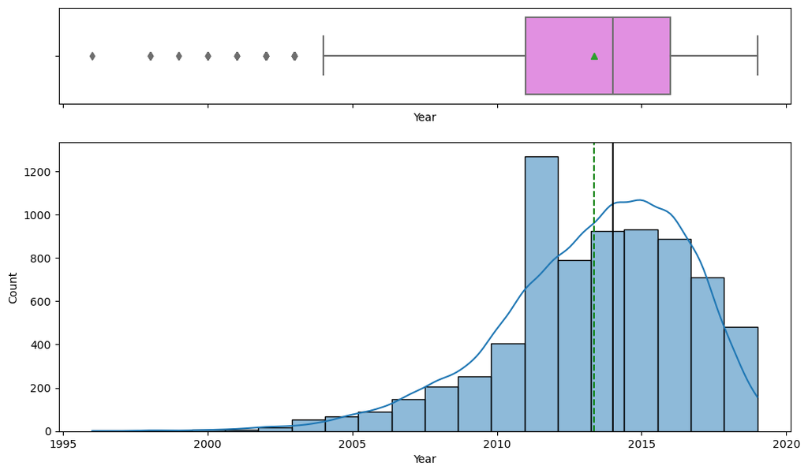

```python
#create histogram and boxplot for year
histogram_boxplot(df, 'Year', kde = True, bins = 20)
```

- Look into the outliers. Might be worth it to remove cars that are older than 2003.

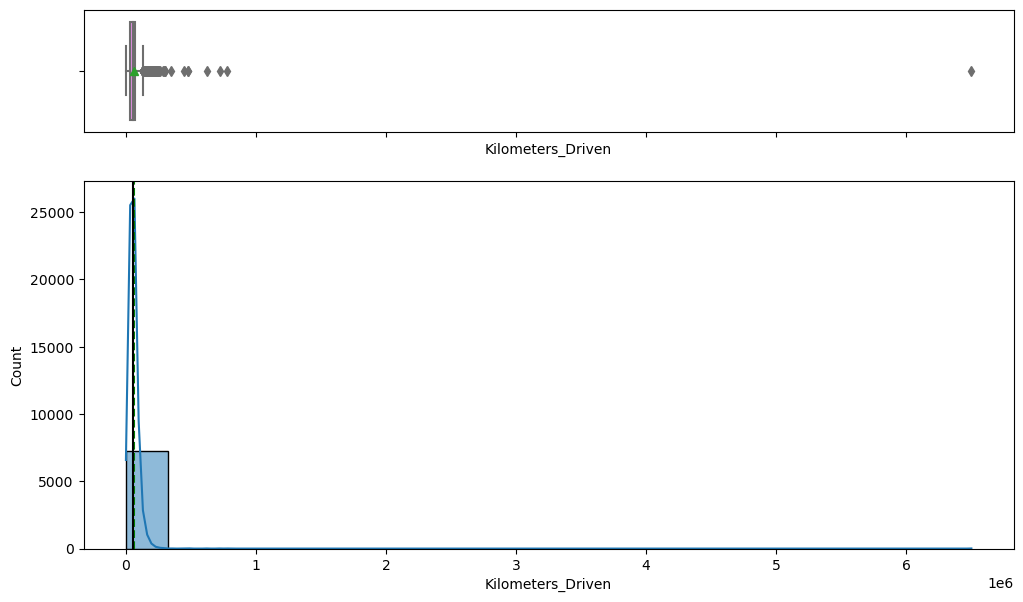

```python
#create histogram and boxplot for kilometers driven
histogram_boxplot(df, 'Kilometers_Driven', kde = True, bins = 20)
```

- Remove the outlier then replot

```python
#Finding the row with the max kilometers driven
max_kilo = df['Kilometers_Driven'].max()
max_kilo_row = df[df['Kilometers_Driven'] == max_kilo]
max_kilo_row
```

|  | Name | Location | Year | Kilometers_Driven | Fuel_Type | Transmission | Owner_Type | Mileage | Engine | Power | Seats | New_price | Price |
| --- | --- | --- | --- | --- | --- | --- | --- | --- | --- | --- | --- | --- | --- |
| 2328 | BMW X5 xDrive 30d M Sport | Chennai | 2017 | 6500000 | Diesel | Automatic | First | 15.97 | 2993.0 | 258.0 | 5.0 | NaN | 65.0 |

```python
#Cutting off the last two zeros to make the value 65,000 instead of 6,500,000
df.loc[2328, 'Kilometers_Driven'] = 65000
```

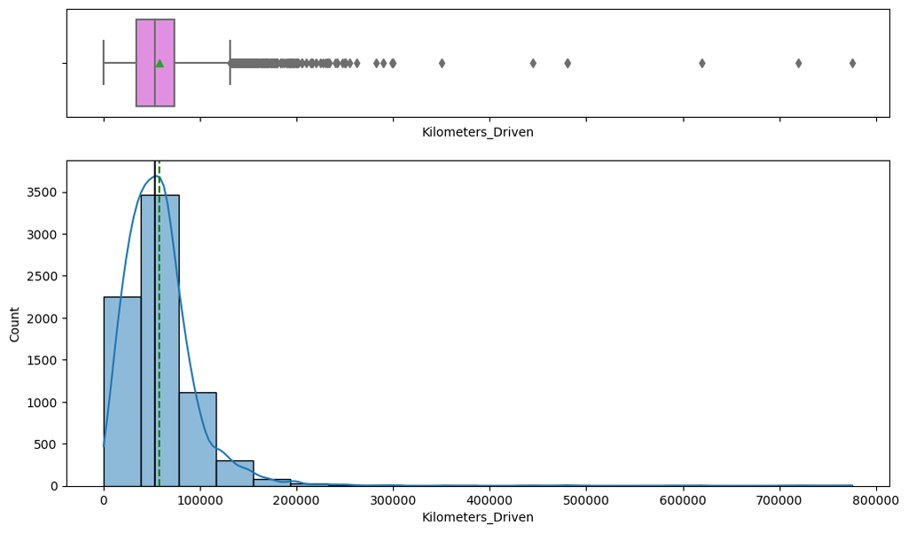

```python
#create histogram and boxplot for kilometers driven with the max changed
histogram_boxplot(df, 'Kilometers_Driven', kde = True, bins = 20)
```

- The data is heavily skewed to the right. Looks like a lot of outliers.
- Will want to log kilometers driven.

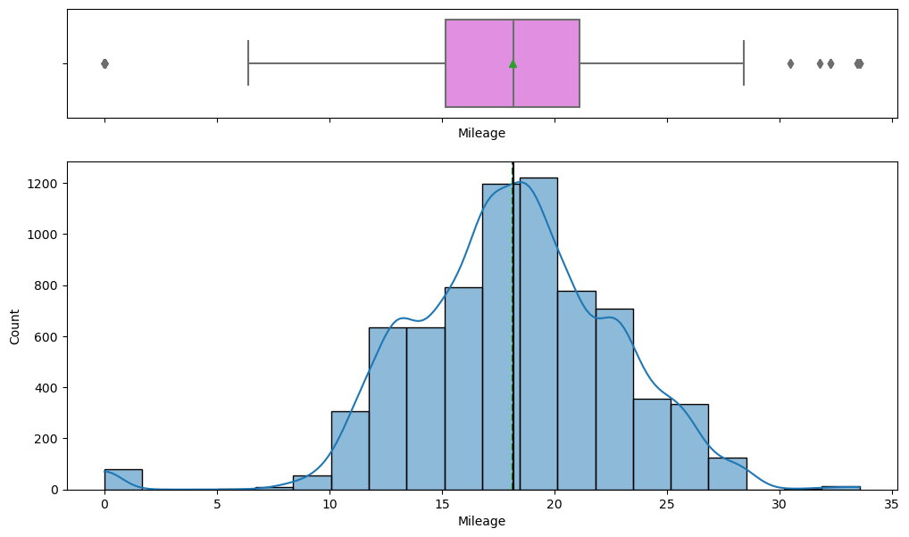

```python
#create histogram and boxplot for mileage
histogram_boxplot(df, 'Mileage', kde = True, bins = 20)
```

- The boxplot is fairly uniform.

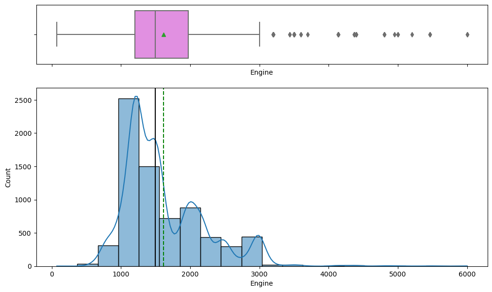

```python
#create histogram and boxplot for engine
histogram_boxplot(df, 'Engine', kde = True, bins = 20)
```

- Slightly skewed to the right.

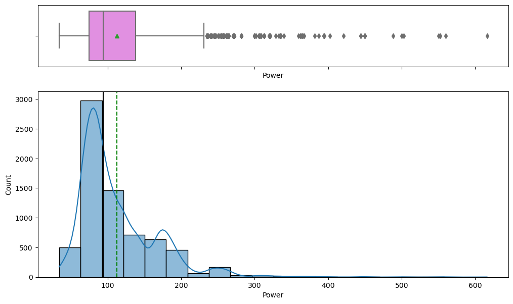

```python
#create histogram and boxplot for power
histogram_boxplot(df, 'Power', kde = True, bins = 20)
```

- Slightly skewed to the right.

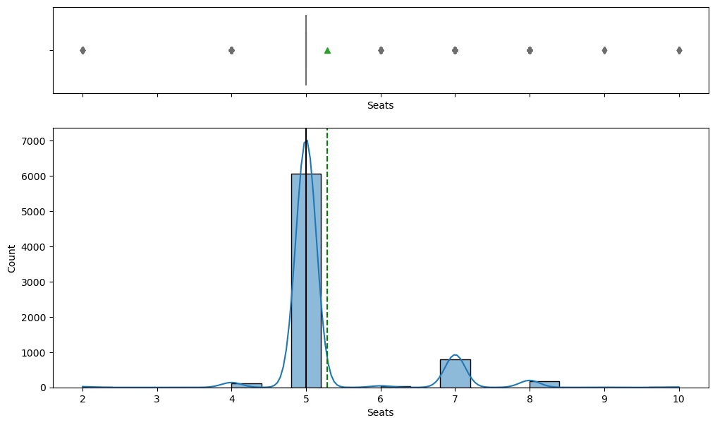

```python
#create histogram and boxplot for seats
histogram_boxplot(df, 'Seats', kde = True, bins = 20)
```

-This looks fine. Most cars have 5 seats.

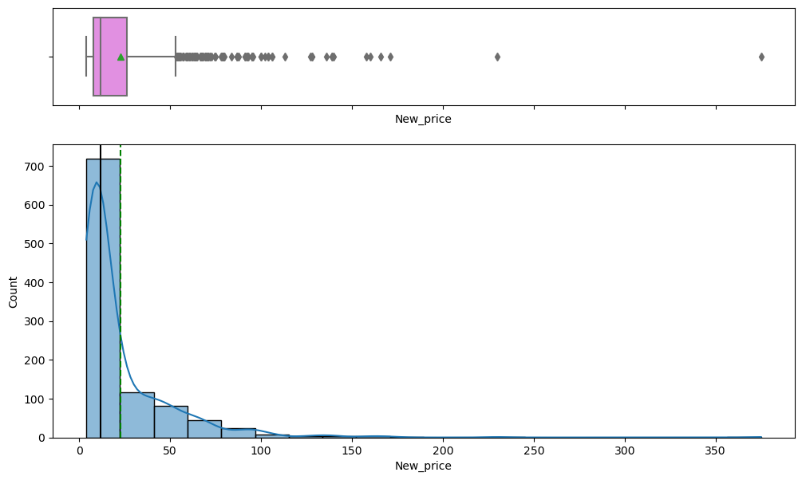

```python
#create histogram and boxplot for year new price
histogram_boxplot(df, 'New_price', kde = True, bins = 20)
```

- Lots of missing values in this column. Will need to fix this, then may want to plot again.
- Data is slightly skewed to the right.

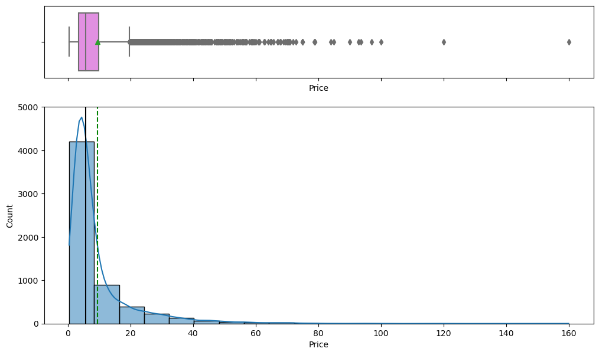

```python
#create histogram and boxplot for price
histogram_boxplot(df, 'Price', kde = True, bins = 20)
```

- Lots of missing prices here as well.
- Data is heavily skewed to the right.
- Log the price.

```python
#Log transformation of kilometers driven
df['Kilometers_Driven_log'] = np.log(df['Kilometers_Driven'])
```

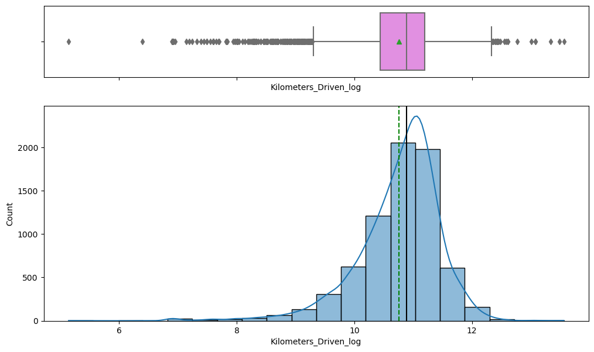

```python
histogram_boxplot(df, 'Kilometers_Driven_log', kde = True, bins = 20)
```

- Still a decent amount of outliers, but the graph looks much better.

```python
#Log transformation of price, rerun this when the missing values are changed
df['Price_log'] = np.log(df['Price'])
```

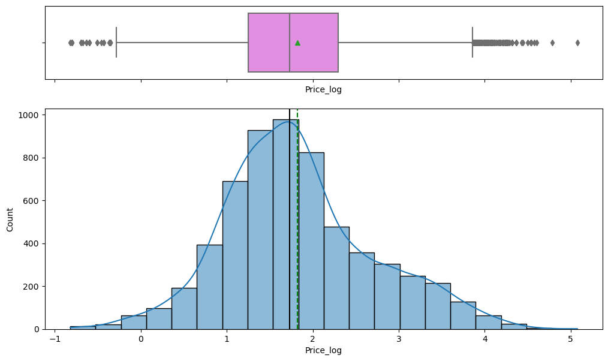

```python
histogram_boxplot(df, 'Price_log', kde = True, bins = 20)
```

- Also looks like a decent amount of outliers.
- Looks like after logging the Price, some values are now below 0.
- Add this to comment and ask about it.

**Categorical Analysis**

```python
#Showing the break down of the categorical columns
for i in cat_cols:
    print(df[i].value_counts(normalize = True))

    print('*' * 40)
```

```
Mahindra XUV500 W8 2WD                  0.007584
Maruti Swift VDI                        0.006757
Maruti Swift Dzire VDI                  0.005792
Honda City 1.5 S MT                     0.005378
Maruti Swift VDI BSIV                   0.005102
                                          ...
Chevrolet Beat LT Option                0.000138
Skoda Rapid 1.6 MPI AT Elegance Plus    0.000138
Ford EcoSport 1.5 TDCi Ambiente         0.000138
Hyundai i10 Magna 1.1 iTech SE          0.000138
Hyundai Elite i20 Magna Plus            0.000138
Name: Name, Length: 2041, dtype: float64
Mumbai        0.130723
Hyderabad     0.120794
Coimbatore    0.106453
Kochi         0.106453
Pune          0.105488
Delhi         0.091009
Kolkata       0.090182
Chennai       0.081495
Jaipur        0.068809
Bangalore     0.060673
Ahmedabad     0.037921
Name: Location, dtype: float64
Diesel      0.531164
Petrol      0.458356
CNG         0.008549
LPG         0.001655
Electric    0.000276
Name: Fuel_Type, dtype: float64
Manual       0.717457
Automatic    0.282543
Name: Transmission, dtype: float64
First             0.820601
Second            0.158853
Third             0.018891
Fourth & Above    0.001655
Name: Owner_Type, dtype: float64
```

```python
# Function to create labeled barplots

def labeled_barplot(data, feature, perc = False, n = None):
    """
    Barplot with percentage at the top

    data: dataframe
    feature: dataframe column
    perc: whether to display percentages instead of count (default is False)
    n: displays the top n category levels (default is None, i.e., display all levels)
    """

    total = len(data[feature])            # Length of the column
    count = data[feature].nunique()
    if n is None:
        plt.figure(figsize = (count + 1, 5))
    else:
        plt.figure(figsize = (n + 1, 5))

    plt.xticks(rotation = 90, fontsize = 15)
    ax = sns.countplot(
        data = data,
        x = feature,
        palette = "Paired",
        order = data[feature].value_counts().index[:n].sort_values(),
    )

    for p in ax.patches:
        if perc == True:
            label = "{:.1f}%".format(
                100 * p.get_height() / total
            )                              # Percentage of each class of the category
        else:
            label = p.get_height()         # Count of each level of the category

        x = p.get_x() + p.get_width() / 2  # Width of the plot
        y = p.get_height()                 # Height of the plot

        ax.annotate(
            label,
            (x, y),
            ha = "center",
            va = "center",
            size = 12,
            xytext = (0, 5),
            textcoords = "offset points",
        )                                 # Annotate the percentage

    plt.show()                            # Show the plot
```

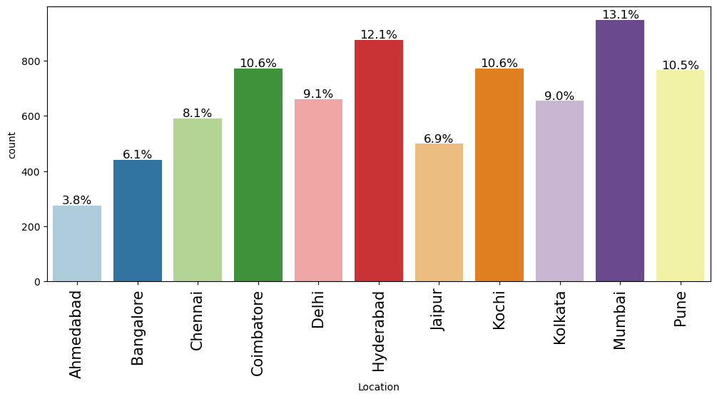

```python
#Labeled barplot for Location
labeled_barplot(df, 'Location', perc = True)
```

- This is similar to the categorical analysis above.
- Mumbai, Hyderabad, Coimbatore, Kochi, and Pune are all above 10%. The way they are typed is from highest to lowest.
- Delhi, Kolkata, Chennai, Jaipur, Bangalore, and Ahmedabad are all below 10%. They range from 9.1% to 3.8%.

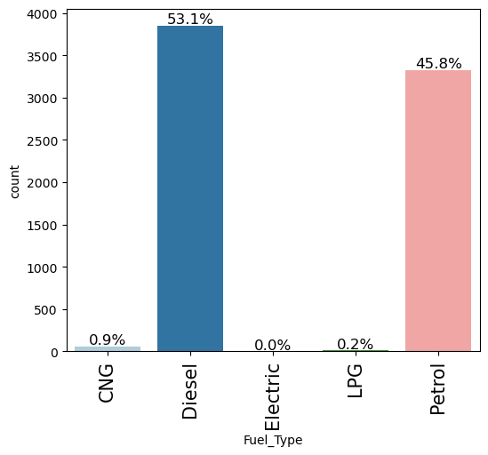

```python
#labeled barplot for fuel type
labeled_barplot(df, 'Fuel_Type', perc = True)
```

```python
sum_electric = df['Fuel_Type'].value_counts().get('Electric')
```

```python
print(sum_electric)
```

```
2
```

- This helps to show how diesel and petrol make up most of the cars fuel types.
- CNG is third with .9%.
- LPG is fourth at .2%.
- Electric only has 2 cars in it.

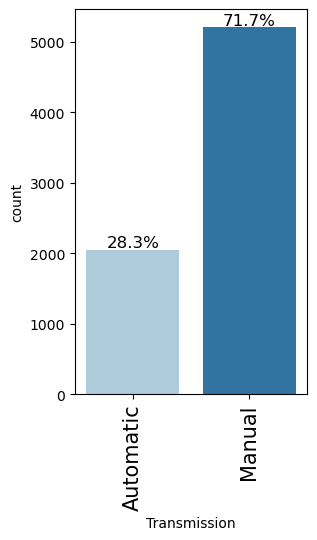

```python
#labeled barplot for transmission
labeled_barplot(df, 'Transmission', perc = True)
```

- 71.7% of cars are manual.
- 28.3% of cars are automatic.

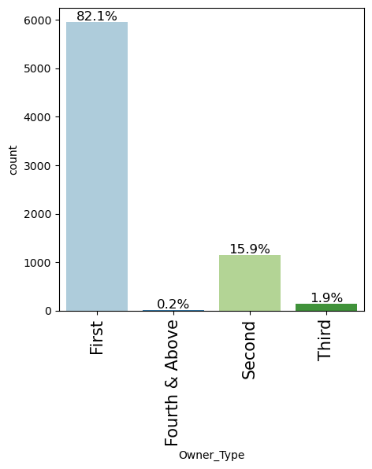

```python
#labeled barplot for owner type
labeled_barplot(df, 'Owner_Type', perc = True)
```

```python
four_previous = df['Owner_Type'].value_counts().get('Fourth & Above')
```

```python
print(four_previous)
```

```
12
```

## **Bivariate Analysis**

**Questions:**

1. Plot a scatter plot for the log transformed values(if log_transformation done in previous steps)?
2. What can we infer form the correlation heatmap? Is there correlation between the dependent and independent variables?
3. Plot a box plot for target variable and categorical variable 'Location' and write your observations?

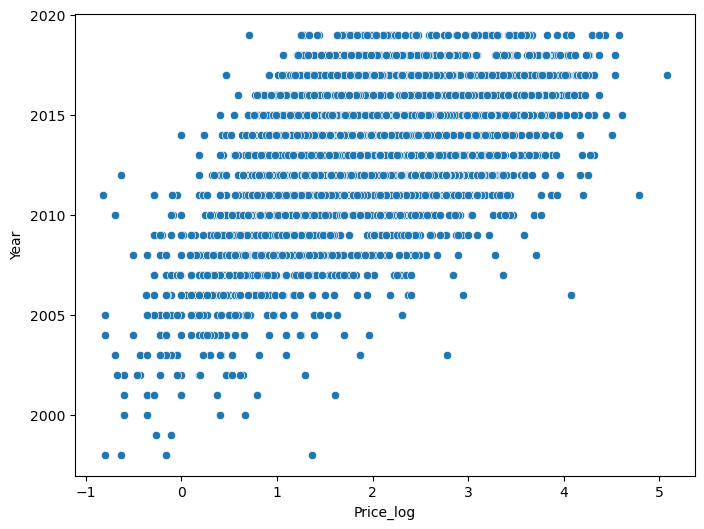

```python
#Create scatterplot for Price log and Year
plt.figure(figsize = [8,6])
sns.scatterplot(x = df.Price_log, y = df.Year)
plt.show()
```

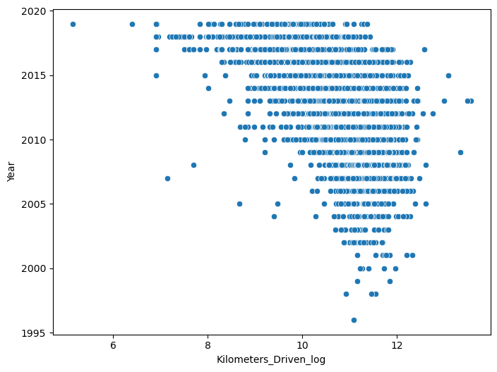

```python
#Create scatterplot for kilometer log and year
plt.figure(figsize = [8,6])
sns.scatterplot(x = df.Kilometers_Driven_log, y = df.Year)
plt.show()
```

- The older vehicles look to have more mileage.
- The data is pretty evenly spread out, which is good because the original column has had log used on it.

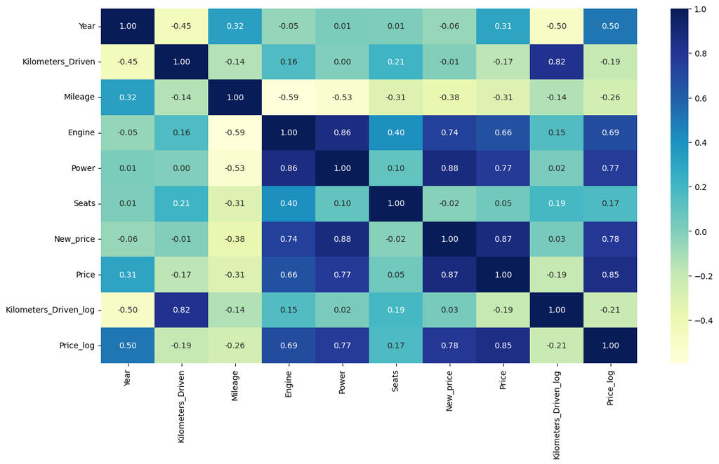

```python
#Plotting the correlation between variables
plt.figure(figsize = (15,8))

sns.heatmap(df.corr(), annot = True, fmt = '0.2f', cmap = 'YlGnBu')

plt.show()
```

Do bivariate analysis to visualize the relationship between the features having significant correlations (>= 0.7 or <= -0.7).

- Engine and New_price = .74
- Engine and Power = .86
- Power and Price_log = .77
- Power and Price = .77
- Power and New_price = .88
- New_price and Price_log = .78
- New_price and Price = .87
- Year and kilometers driven log have a negative correlation.
- Year and new price have a negative correlation.
- Year and engine have a negative correlation.
- Year and kilometers driven have a negative correlation.
- Kilometers driven and price log have a negative correlation.
- Kilometers driven and price have a negative correlation.
- Kilometers driven and mileage have a negative correlation.
- Kilometers driven and year have a negative correlation.
- Mileage has a negative correlation with everything except Year.

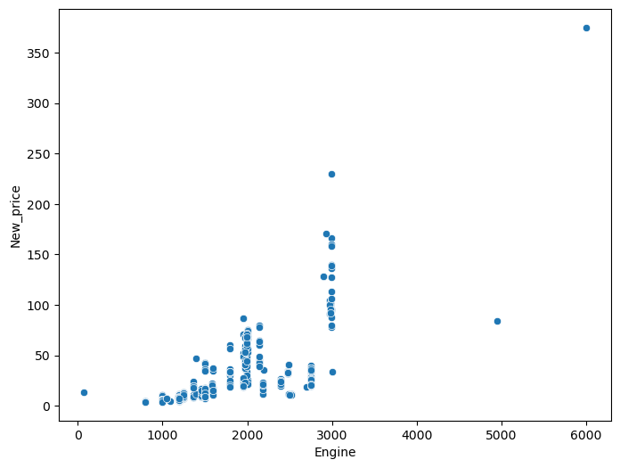

```python
#Create scatterplot for Engine and New_price
plt.figure(figsize = [8,6])
sns.scatterplot(x = df.Engine, y = df.New_price)
plt.show()
```

- The larger the engine, the higher the price for a new vehicle.

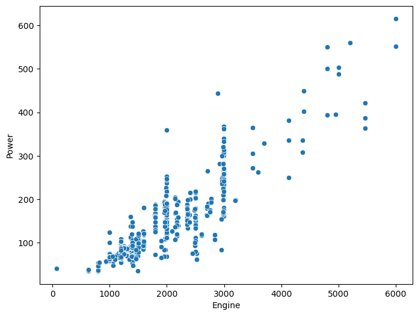

```python
#Create scatterplot for Engine and Power
plt.figure(figsize = [8,6])
sns.scatterplot(x = df.Engine, y = df.Power)
plt.show()
```

- The larger the engine, the more power the vehicle has.

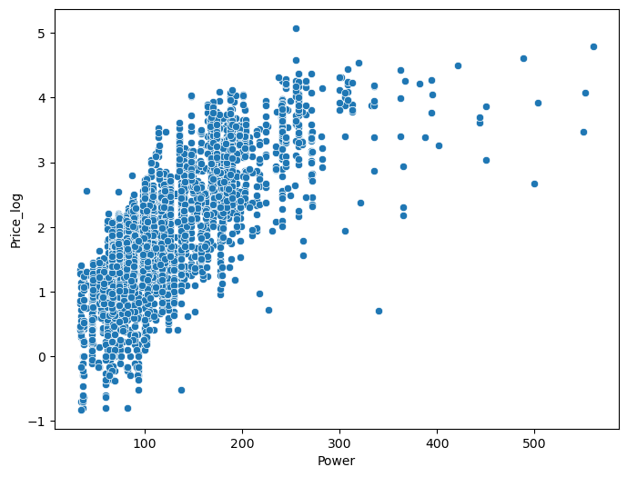

```python
#Create scatterplot for Power and Price_log
plt.figure(figsize = [8,6])
sns.scatterplot(x = df.Power, y = df.Price_log)
plt.show()
```

- Vehicles with more power tend to have a higher price.

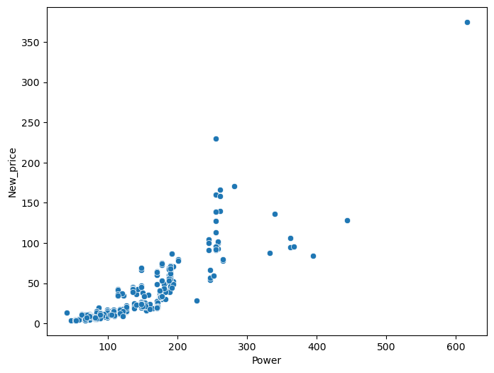

```python
#Create scatterplot for Power and New_price
plt.figure(figsize = [8,6])
sns.scatterplot(x = df.Power, y = df.New_price)
plt.show()
```

- Vehicles with more power tend to be more expensive when they are new.

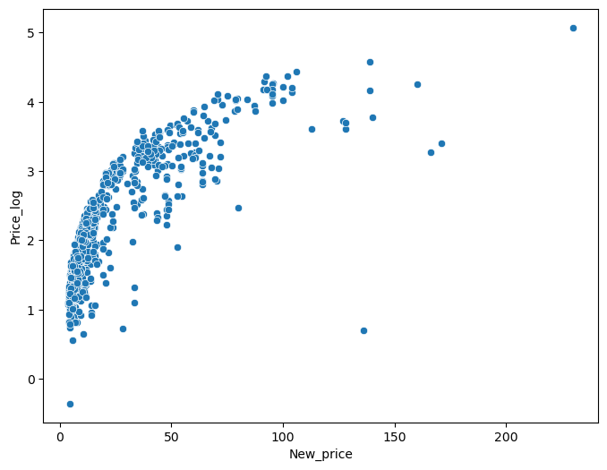

```python
#Create scatterplot for New_price and Price_log
plt.figure(figsize = [8,6])
sns.scatterplot(x = df.New_price, y = df.Price_log)
plt.show()
```

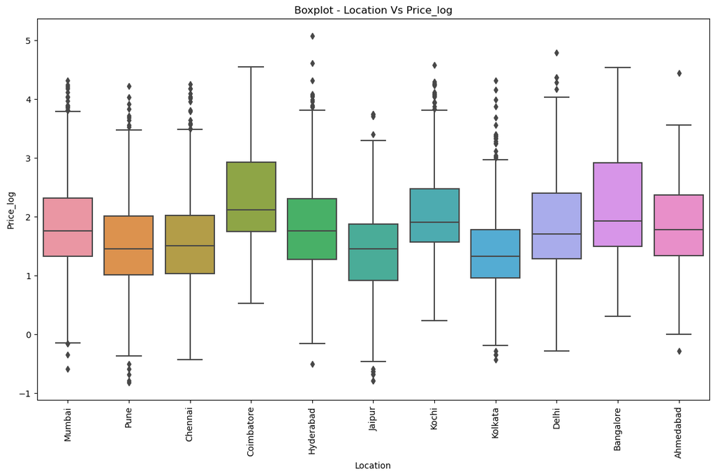

```python
#Boxplot for Price_log and location
plt.figure(figsize = [14, 8])
sns.boxplot(data = df, x = df.Location, y = df.Price_log)
plt.xticks(rotation = 90)
plt.title("Boxplot - Location Vs Price_log")
plt.xlabel("Location")
plt.ylabel("Price_log")
plt.show()
```

- Bangalore and Coimbatore seem to have more expensive vehicles based off the boxplot.
- Pune, Chennai, Jaipur, and Kolkata seem to have the lower priced vehicles.

### **Feature Engineering**

**Think about it:** The `Name` column in the current format might not be very useful in our analysis. Since the name contains both the brand name and the model name of the vehicle, the column would have too many unique values to be useful in prediction. Can we extract that information from that column?

- **Hint:** With 2041 unique names, car names are not going to be great predictors of the price in our current data. But we can process this column to extract important information for example brand name.

```python
#Checking how many unique values are in Name
df['Name'].nunique()
```

```
2041
```

```python
# Extract Brand Names
df["Brand"] = df["Name"].apply(lambda x: x.split(" ")[0].lower())
```

```python
#Seeing how many unique brand names there are
df['Brand'].nunique()
```

```
32
```

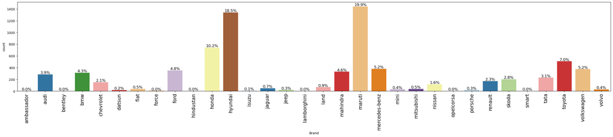

```python
#Labeled barplot for Brand
labeled_barplot(df, 'Brand', perc = True)
```

- Maruti has the most vehicles with 20%.
- Hyundai is second with 18.5%.
- Honda is third with 10.2%.
- Toyota is fourth with 7%.
- Volkswagen and Mercedes both have 5.2%.
- Audi, BMS, Chevrolet, Ford, Mahindra, Nissan, Renault, Skoda, and Tata all range from 1.6% to 4.8%.
- Ambassador, Bentley, Datsun, Fiat, Force, Hindustan, Isuzu, Jaguar, Jeep, Lamborghini, Land, Mini, Mitsubishi, Opelcorsa, Porsche, Smart, and Volvo all make up less than 1%.

```python
#Extract Model Names
df["Model"] = df["Name"].apply(lambda x: " ".join(x.split(" ")[1:]).strip())
```

```python
#Checking how many unique model names there are
df['Model'].nunique()
```

```
2041
```

```python
#Trying to find more information on the model
df['Model'].describe()
```

```
count              7252
unique             2041
top       XUV500 W8 2WD
freq                 55
Name: Model, dtype: object
```

- There are 7252 rows for model.
- There are 2041 unique models.
- XUV500 W8 2WD is the most common with 55 vehicles.

```python
#Printing the name, brand, and model
print(df[['Name', 'Brand', 'Model']].sample(10))
```

```
                                           Name          Brand  \
4987             Mercedes-Benz E-Class 230 E AT  mercedes-benz
4387                         BMW 7 Series 730Ld            bmw
5866  Volkswagen Vento Magnific 1.6 Comfortline     volkswagen
2526                     Hyundai i20 Sportz 1.2        hyundai
775                      Toyota Fortuner 4x4 MT         toyota
7010                      Maruti Swift VDI BSIV         maruti
3830                     Toyota Fortuner 4x2 AT         toyota
4792                 Toyota Fortuner 3.0 Diesel         toyota
1121              Maruti Swift VDi BSIII W/ ABS         maruti
4235                         Maruti Wagon R LXI         maruti

                               Model
4987                E-Class 230 E AT
4387                  7 Series 730Ld
5866  Vento Magnific 1.6 Comfortline
2526                  i20 Sportz 1.2
775                  Fortuner 4x4 MT
7010                  Swift VDI BSIV
3830                 Fortuner 4x2 AT
4792             Fortuner 3.0 Diesel
1121          Swift VDi BSIII W/ ABS
4235                     Wagon R LXI
```

- I wanted a better understanding of why the unique values of the models is so high.
- Is there a better way to group the models together?

### **Missing value treatment**

```python
df.isnull().sum()
```

```
Name                        0
Location                    0
Year                        0
Kilometers_Driven           0
Fuel_Type                   0
Transmission                0
Owner_Type                  0
Mileage                     2
Engine                     46
Power                     175
Seats                      53
New_price                6246
Price                    1233
Kilometers_Driven_log       0
Price_log                1233
Brand                       0
Model                       0
dtype: int64
```

- Name, location, year, kilometers driven, fuel type, transmission, owner type, kilometers driven log, brand, and model all have no missing values.
- Mileage has 2 missing values.
- Engine has 46 missing values.
- Power has 175 missing values.
- Seats has 53 missing values.
- New price has 6,246 missing values.
- Price has 1,233 missing values.
- Price log has 1,233 missing values.

**Missing Values for seats**

```python
# Group the data by Brand and Model and count null values in Seats
null_seats = df.groupby(['Brand','Model'])['Seats'].apply(lambda x: x.isnull().sum()).reset_index(name='Null_Seats_Count')
```

```python
# Display rows with null values in Seats for each Brand and Model
print(null_seats[null_seats['Null_Seats_Count'] > 0])
```

```
         Brand                                    Model  Null_Seats_Count
115        bmw                      5 Series 520d Sedan                 7
246       fiat                        Punto 1.2 Dynamic                 1
247       fiat                        Punto 1.3 Emotion                 1
248       fiat                        Punto 1.4 Emotion                 2
299       ford                   Endeavour Hurricane LE                 1
352       ford                              Figo Diesel                 1
443      honda                    CR-V AT With Sun Roof                 1
448      honda                              City 1.3 DX                 1
452      honda                             City 1.5 EXI                 1
455      honda                             City 1.5 GXI                 3
523      honda                         Jazz 2020 Petrol                 1
528      honda                      Jazz Select Edition                 1
644    hyundai                  Santro GLS II - Euro II                 4
648    hyundai                        Santro LP zipPlus                 1
657    hyundai                           Santro Xing XG                 2
841    hyundai                    i20 new Sportz AT 1.4                 1
890       land                  Rover Range Rover 3.0 D                 2
899       land  Rover Range Rover Sport 2005 2012 Sport                 1
995   mahindra                               TUV 300 P4                 1
1172    maruti                               Estilo LXI                 3
1223    maruti                            Swift 1.3 LXI                 2
1224    maruti                        Swift 1.3 VXI ABS                 1
1225    maruti                            Swift 1.3 VXi                 8
1226    maruti                            Swift 1.3 ZXI                 1
1329    maruti                               Wagon R Vx                 1
1608     skoda                   Laura 1.8 TSI Ambition                 1
1868    toyota           Etios Liva Diesel TRD Sportivo                 1
1872    toyota                             Etios Liva V                 2
```

```python
# Calculate the median seats for each unique combination of Brand and Model
median_seats_by_brand_model = df.groupby(['Brand', 'Model'])['Seats'].transform('median')
```

```python
# Fill the missing values in 'Seats' column with the corresponding median for each Brand and Model
df['Seats'].fillna(median_seats_by_brand_model, inplace=True)
```

```python
# Creating variable for desired Model
desired_model = "5 Series 520d Sedan"

# Use the loc method to filter rows with the specific model name
result = df.loc[df['Model'] == desired_model]

# Display the results
print(result)
```

```
                         Name   Location  Year  Kilometers_Driven Fuel_Type  \
2530  BMW 5 Series 520d Sedan      Kochi  2014              64158    Diesel
2623  BMW 5 Series 520d Sedan       Pune  2012              95000    Diesel
3272  BMW 5 Series 520d Sedan     Mumbai  2008              81000    Diesel
3520  BMW 5 Series 520d Sedan      Delhi  2012              90000    Diesel
4577  BMW 5 Series 520d Sedan      Delhi  2012              72000    Diesel
6643  BMW 5 Series 520d Sedan  Bangalore  2009             150000    Diesel
6880  BMW 5 Series 520d Sedan    Chennai  2009              95000    Diesel

     Transmission Owner_Type  Mileage  Engine  Power  Seats  New_price  Price  \
2530    Automatic      First    18.48     NaN    NaN    NaN        NaN  17.89
2623    Automatic     Second    18.48     NaN    NaN    NaN        NaN  18.00
3272    Automatic     Second    18.48     NaN    NaN    NaN        NaN  10.50
3520    Automatic      First    18.48     NaN    NaN    NaN        NaN  14.50
4577    Automatic      Third    18.48     NaN    NaN    NaN        NaN  13.85
6643    Automatic     Second    18.48     NaN    NaN    NaN        NaN    NaN
6880    Automatic     Second    18.48     NaN    NaN    NaN        NaN    NaN

      Kilometers_Driven_log  Price_log Brand                Model
2530              11.069104   2.884242   bmw  5 Series 520d Sedan
2623              11.461632   2.890372   bmw  5 Series 520d Sedan
3272              11.302204   2.351375   bmw  5 Series 520d Sedan
3520              11.407565   2.674149   bmw  5 Series 520d Sedan
4577              11.184421   2.628285   bmw  5 Series 520d Sedan
6643              11.918391        NaN   bmw  5 Series 520d Sedan
6880              11.461632        NaN   bmw  5 Series 520d Sedan
```

```python
#Making the seats for BMW 5 Series 520d Sedan equal to 5. Found seats from google search
df.loc[2530, 'Seats'] = 5
df.loc[2623, 'Seats'] = 5
df.loc[3272, 'Seats'] = 5
df.loc[3520, 'Seats'] = 5
df.loc[4577, 'Seats'] = 5
df.loc[6643, 'Seats'] = 5
df.loc[6880, 'Seats'] = 5
```

```python
# Creating variable for desired Model
desired_model2 = "Punto 1.2 Dynamic"

# Use the loc method to filter rows with the specific model name
result2 = df.loc[df['Model'] == desired_model2]

# Display the results
print(result2)
```

```
                        Name Location  Year  Kilometers_Driven Fuel_Type  \
4697  Fiat Punto 1.2 Dynamic    Kochi  2017              17941    Petrol

     Transmission Owner_Type  Mileage  Engine  Power  Seats  New_price  Price  \
4697       Manual      First     15.7     NaN    NaN    NaN        NaN   3.93

      Kilometers_Driven_log  Price_log Brand              Model
4697               9.794844   1.368639  fiat  Punto 1.2 Dynamic
```

```python
#Making the seats for Fiat Punto 1.2 Dynamic equal to 5. Found seats from google search
df.loc[4697, 'Seats'] = 5
```

```python
# Creating variable for desired Model
desired_model3 = "Punto 1.3 Emotion"

# Use the loc method to filter rows with the specific model name
result3 = df.loc[df['Model'] == desired_model3]

# Display the results
print(result3)
```

```
                        Name Location  Year  Kilometers_Driven Fuel_Type  \
4011  Fiat Punto 1.3 Emotion     Pune  2011              45271    Diesel

     Transmission Owner_Type  Mileage  Engine  Power  Seats  New_price  Price  \
4011       Manual      First     20.3     NaN    NaN    NaN        NaN    2.6

      Kilometers_Driven_log  Price_log Brand              Model
4011              10.720422   0.955511  fiat  Punto 1.3 Emotion
```

```python
#Making the seats for Punto 1.3 Emotion equal to 5. Found seats from google search
df.loc[4011, 'Seats'] = 5
```

```python
# Creating variable for desired Model
desired_model4 = "Punto 1.4 Emotion"

# Use the loc method to filter rows with the specific model name
result4 = df.loc[df['Model'] == desired_model4]

# Display the results
print(result4)
```

```
                        Name Location  Year  Kilometers_Driven Fuel_Type  \
4952  Fiat Punto 1.4 Emotion  Kolkata  2010              47000    Petrol
6677  Fiat Punto 1.4 Emotion   Jaipur  2010              65000    Petrol

     Transmission Owner_Type  Mileage  Engine  Power  Seats  New_price  Price  \
4952       Manual      First     14.6     NaN    NaN    NaN        NaN   1.49
6677       Manual      Third     14.6     NaN    NaN    NaN        NaN    NaN

      Kilometers_Driven_log  Price_log Brand              Model
4952              10.757903   0.398776  fiat  Punto 1.4 Emotion
6677              11.082143        NaN  fiat  Punto 1.4 Emotion
```

```python
#Making the seats for Punto 1.4 Emotion equal to 5. Found seats from google search
df.loc[4952, 'Seats'] = 5
df.loc[6677, 'Seats'] = 5
```

```python
# Creating variable for desired Model
desired_model5 = "Endeavour Hurricane LE"

# Use the loc method to filter rows with the specific model name
result5 = df.loc[df['Model'] == desired_model5]

# Display the results
print(result5)
```

```
                             Name Location  Year  Kilometers_Driven Fuel_Type  \
3800  Ford Endeavour Hurricane LE   Mumbai  2012             129000    Diesel

     Transmission Owner_Type  Mileage  Engine  Power  Seats  New_price  Price  \
3800    Automatic      First     12.8  2953.0    NaN    NaN        NaN    7.0

      Kilometers_Driven_log  Price_log Brand                   Model
3800              11.767568    1.94591  ford  Endeavour Hurricane LE
```

```python
#Making the seats for Endeavour Hurricane LE equal to 7. Found seats from google search
df.loc[3800, 'Seats'] = 7
```

```python
# Creating variable for desired Model
desired_model6 = "Figo Diesel"

# Use the loc method to filter rows with the specific model name
result6 = df.loc[df['Model'] == desired_model6]

# Display the results
print(result6)
```

```
                 Name   Location  Year  Kilometers_Driven Fuel_Type  \
229  Ford Figo Diesel  Bangalore  2015              70436    Diesel

    Transmission Owner_Type  Mileage  Engine  Power  Seats  New_price  Price  \
229       Manual      First      0.0  1498.0   99.0    NaN        NaN    3.6

     Kilometers_Driven_log  Price_log Brand        Model
229               11.16246   1.280934  ford  Figo Diesel
```

```python
#Making the seats for Figo Diesel equal to 5. Found seats from google search
df.loc[229, 'Seats'] = 5
```

```python
# Creating variable for desired Model
desired_model7 = "CR-V AT With Sun Roof"

# Use the loc method to filter rows with the specific model name
result7 = df.loc[df['Model'] == desired_model7]

# Display the results
print(result7)
```

```
                             Name Location  Year  Kilometers_Driven Fuel_Type  \
3810  Honda CR-V AT With Sun Roof  Kolkata  2013              27000    Petrol

     Transmission Owner_Type  Mileage  Engine  Power  Seats  New_price  Price  \
3810    Automatic      First     14.0     NaN    NaN    NaN        NaN  11.99

      Kilometers_Driven_log  Price_log  Brand                  Model
3810              10.203592   2.484073  honda  CR-V AT With Sun Roof
```

```python
#Making the seats for CR-V AT With Sun Roof equal to 7. Found seats from google search
df.loc[3810, 'Seats'] = 7
```

```python
# Creating variable for desired Model
desired_model8 = ("City 1.3 DX")

# Use the loc method to filter rows with the specific model name
result8 = df.loc[df['Model'] == desired_model8]

# Display the results
print(result8)
```

```
                   Name Location  Year  Kilometers_Driven Fuel_Type  \
1294  Honda City 1.3 DX    Delhi  2009              55005    Petrol

     Transmission Owner_Type  Mileage  Engine  Power  Seats  New_price  Price  \
1294       Manual      First     12.8     NaN    NaN    NaN        NaN    3.2

      Kilometers_Driven_log  Price_log  Brand        Model
1294              10.915179   1.163151  honda  City 1.3 DX
```

```python
#Making the seats for City 1.3 DX equal to 5. Found seats from google search
df.loc[1294, 'Seats'] = 5
```

```python
# Creating variable for desired Model
desired_model9 = ("Jazz 2020 Petrol")

# Use the loc method to filter rows with the specific model name
result9 = df.loc[df['Model'] == desired_model9]

# Display the results
print(result9)
```

```
                        Name Location  Year  Kilometers_Driven Fuel_Type  \
6957  Honda Jazz 2020 Petrol    Kochi  2019              11574    Petrol

     Transmission Owner_Type  Mileage  Engine  Power  Seats  New_price  Price  \
6957       Manual      First      0.0  1199.0   88.7    NaN        NaN    NaN

      Kilometers_Driven_log  Price_log  Brand             Model
6957               9.356516        NaN  honda  Jazz 2020 Petrol
```

```python
#Making the seats for Jazz 2020 Petrol equal to 5. Found seats from google search
df.loc[6957, 'Seats'] = 5
```

```python
# Creating variable for desired Model
desired_model10 = ("Santro GLS II - Euro II")

# Use the loc method to filter rows with the specific model name
result10 = df.loc[df['Model'] == desired_model10]

# Display the results
print(result10)
```

```
                                 Name   Location  Year  Kilometers_Driven  \
2542  Hyundai Santro GLS II - Euro II  Bangalore  2011              65000
2780  Hyundai Santro GLS II - Euro II       Pune  2009             100000
2842  Hyundai Santro GLS II - Euro II  Bangalore  2012              43000
3522  Hyundai Santro GLS II - Euro II      Kochi  2012              66400

     Fuel_Type Transmission Owner_Type  Mileage  Engine  Power  Seats  \
2542    Petrol       Manual     Second      0.0     NaN    NaN    NaN
2780    Petrol       Manual      First      0.0     NaN    NaN    NaN
2842    Petrol       Manual      First      0.0     NaN    NaN    NaN
3522    Petrol       Manual      First      0.0     NaN    NaN    NaN

      New_price  Price  Kilometers_Driven_log  Price_log    Brand  \
2542        NaN   3.15              11.082143   1.147402  hyundai
2780        NaN   1.60              11.512925   0.470004  hyundai
2842        NaN   3.25              10.668955   1.178655  hyundai
3522        NaN   2.66              11.103452   0.978326  hyundai

                        Model
2542  Santro GLS II - Euro II
2780  Santro GLS II - Euro II
2842  Santro GLS II - Euro II
3522  Santro GLS II - Euro II
```

```python
#Making the seats for Santro GLS II - Euro II equal to 5. Found seats from google search
df.loc[2542, 'Seats'] = 5
df.loc[2780, 'Seats'] = 5
df.loc[2842, 'Seats'] = 5
df.loc[3522, 'Seats'] = 5
```

```python
# Creating variable for desired Model
desired_model11 = ("Santro LP zipPlus")

# Use the loc method to filter rows with the specific model name
result11 = df.loc[df['Model'] == desired_model11]

# Display the results
print(result11)
```

```
                           Name    Location  Year  Kilometers_Driven  \
2096  Hyundai Santro LP zipPlus  Coimbatore  2004              52146

     Fuel_Type Transmission Owner_Type  Mileage  Engine  Power  Seats  \
2096    Petrol       Manual      First      0.0     NaN    NaN    NaN

      New_price  Price  Kilometers_Driven_log  Price_log    Brand  \
2096        NaN   1.93              10.861803    0.65752  hyundai

                  Model
2096  Santro LP zipPlus
```

```python
#Making the seats for Santro LP zipPlus equal to 5. Found seats from google search
df.loc[2096, 'Seats'] = 5
```

```python
# Creating variable for desired Model
desired_model12 = ("Santro Xing XG")

# Use the loc method to filter rows with the specific model name
result12 = df.loc[df['Model'] == desired_model12]

# Display the results
print(result12)
```

```
                        Name   Location  Year  Kilometers_Driven Fuel_Type  \
4229  Hyundai Santro Xing XG  Bangalore  2005              79000    Petrol
4712  Hyundai Santro Xing XG       Pune  2003              80000    Petrol

     Transmission Owner_Type  Mileage  Engine  Power  Seats  New_price  Price  \
4229       Manual     Second     17.0     NaN    NaN    NaN        NaN   1.65
4712       Manual     Second     17.0     NaN    NaN    NaN        NaN   0.90

      Kilometers_Driven_log  Price_log    Brand           Model
4229              11.277203   0.500775  hyundai  Santro Xing XG
4712              11.289782  -0.105361  hyundai  Santro Xing XG
```

```python
#Making the seats for Santro Xing XG equal to 5. Found seats from google search
df.loc[4229, 'Seats'] = 5
df.loc[4712, 'Seats'] = 5
```

```python
# Creating variable for desired Model
desired_model13 = ("i20 new Sportz AT 1.4")

# Use the loc method to filter rows with the specific model name
result13 = df.loc[df['Model'] == desired_model13]

# Display the results
print(result13)
```

```
                               Name   Location  Year  Kilometers_Driven  \
6544  Hyundai i20 new Sportz AT 1.4  Bangalore  2012              58000

     Fuel_Type Transmission Owner_Type  Mileage  Engine  Power  Seats  \
6544    Petrol    Automatic     Second     15.0     NaN    NaN    NaN

      New_price  Price  Kilometers_Driven_log  Price_log    Brand  \
6544        NaN    NaN              10.968198        NaN  hyundai

                      Model
6544  i20 new Sportz AT 1.4
```

```python
#Making the seats for i20 new Sportz AT 1.4 equal to 4. Found seats from google search
df.loc[6544, 'Seats'] = 4
```

```python
# Creating variable for desired Model
desired_model14 = ("Rover Range Rover 3.0 D")

# Use the loc method to filter rows with the specific model name
result14 = df.loc[df['Model'] == desired_model14]

# Display the results
print(result14)
```

```
                              Name Location  Year  Kilometers_Driven  \
749   Land Rover Range Rover 3.0 D   Mumbai  2008              55001
4152  Land Rover Range Rover 3.0 D   Mumbai  2003              75000

     Fuel_Type Transmission Owner_Type  Mileage  Engine  Power  Seats  \
749     Diesel    Automatic     Second      0.0     NaN    NaN    NaN
4152    Diesel    Automatic     Second      0.0     NaN    NaN    NaN

      New_price  Price  Kilometers_Driven_log  Price_log Brand  \
749         NaN  26.50              10.915107   3.277145  land
4152        NaN  16.11              11.225243   2.779440  land

                        Model
749   Rover Range Rover 3.0 D
4152  Rover Range Rover 3.0 D
```

```python
#Making the seats for Rover Range Rover 3.0 D equal to 6. Found seats from google search says 5-7
df.loc[749, 'Seats'] = 6
df.loc[4152, 'Seats'] = 6
```

```python
# Creating variable for desired Model
desired_model15 = ("Rover Range Rover Sport 2005 2012 Sport")

# Use the loc method to filter rows with the specific model name
result15 = df.loc[df['Model'] == desired_model15]

# Display the results
print(result15)
```

```
                                              Name    Location  Year  \
1460  Land Rover Range Rover Sport 2005 2012 Sport  Coimbatore  2008

      Kilometers_Driven Fuel_Type Transmission Owner_Type  Mileage  Engine  \
1460              69078    Petrol       Manual      First      0.0     NaN

      Power  Seats  New_price  Price  Kilometers_Driven_log  Price_log Brand  \
1460    NaN    NaN        NaN  40.88              11.142992   3.710641  land

                                        Model
1460  Rover Range Rover Sport 2005 2012 Sport
```

```python
#Making the seats for Rover Range Rover Sport 2005 2012 Sport equal to 5. Found seats from google search
df.loc[1460, 'Seats'] = 5
```

```python
# Creating variable for desired Model
desired_model16 = ("TUV 300 P4")

# Use the loc method to filter rows with the specific model name
result16 = df.loc[df['Model'] == desired_model16]

# Display the results
print(result16)
```

```
                     Name Location  Year  Kilometers_Driven Fuel_Type  \
6633  Mahindra TUV 300 P4  Kolkata  2016              27000    Diesel

     Transmission Owner_Type  Mileage  Engine  Power  Seats  New_price  Price  \
6633       Manual      First      0.0     NaN    NaN    NaN        NaN    NaN

      Kilometers_Driven_log  Price_log     Brand       Model
6633              10.203592        NaN  mahindra  TUV 300 P4
```

```python
#Making the seats for TUV 300 P4 equal to 7. Found seats from google search
df.loc[6633, 'Seats'] = 7
```

```python
# Creating variable for desired Model
desired_model17 = ("Estilo LXI")

# Use the loc method to filter rows with the specific model name
result17 = df.loc[df['Model'] == desired_model17]

# Display the results
print(result17)
```

```
                   Name Location  Year  Kilometers_Driven Fuel_Type  \
2369  Maruti Estilo LXI  Chennai  2008              56000    Petrol
3882  Maruti Estilo LXI  Kolkata  2010              40000    Petrol
5893  Maruti Estilo LXI  Chennai  2008              51000    Petrol

     Transmission Owner_Type  Mileage  Engine  Power  Seats  New_price  Price  \
2369       Manual     Second     19.5  1061.0    NaN    NaN        NaN   1.50
3882       Manual     Second     19.5  1061.0    NaN    NaN        NaN   2.50
5893       Manual     Second     19.5  1061.0    NaN    NaN        NaN   1.75

      Kilometers_Driven_log  Price_log   Brand       Model
2369              10.933107   0.405465  maruti  Estilo LXI
3882              10.596635   0.916291  maruti  Estilo LXI
5893              10.839581   0.559616  maruti  Estilo LXI
```

```python
#Making the seats for Estilo LXI  equal to 5. Found seats from google search
df.loc[2369, 'Seats'] = 5
df.loc[3882, 'Seats'] = 5
df.loc[5893, 'Seats'] = 5
```

```python
# Creating variable for desired Model
desired_model18 = ("Swift 1.3 LXI")

# Use the loc method to filter rows with the specific model name
result18 = df.loc[df['Model'] == desired_model18]

# Display the results
print(result18)
```

```
                      Name Location  Year  Kilometers_Driven Fuel_Type  \
2074  Maruti Swift 1.3 LXI     Pune  2011              24255    Petrol
5185  Maruti Swift 1.3 LXI    Delhi  2012              52000    Petrol

     Transmission Owner_Type  Mileage  Engine  Power  Seats  New_price  Price  \
2074       Manual      First     16.1     NaN    NaN    NaN        NaN   3.15
5185       Manual      First     16.1     NaN    NaN    NaN        NaN   3.65

      Kilometers_Driven_log  Price_log   Brand          Model
2074              10.096378   1.147402  maruti  Swift 1.3 LXI
5185              10.858999   1.294727  maruti  Swift 1.3 LXI
```

```python
#Making the seats for Swift 1.3 LXI  equal to 5. Found seats from google search
df.loc[2074, 'Seats'] = 5
df.loc[5185, 'Seats'] = 5
```

```python
# Creating variable for desired Model
desired_model19 = ("Swift 1.3 VXI ABS")

# Use the loc method to filter rows with the specific model name
result19 = df.loc[df['Model'] == desired_model19]

# Display the results
print(result19)
```

```
                          Name Location  Year  Kilometers_Driven Fuel_Type  \
2325  Maruti Swift 1.3 VXI ABS     Pune  2015              67000    Petrol

     Transmission Owner_Type  Mileage  Engine  Power  Seats  New_price  Price  \
2325       Manual      First     16.1     NaN    NaN    NaN        NaN    4.7

      Kilometers_Driven_log  Price_log   Brand              Model
2325              11.112448   1.547563  maruti  Swift 1.3 VXI ABS
```

```python
#Making the seats for Swift 1.3 VXI ABS equal to 5. Found seats from google search
df.loc[2325, 'Seats'] = 5
```

```python
# Creating variable for desired Model
desired_model20 = ("Swift 1.3 VXi")

# Use the loc method to filter rows with the specific model name
result20 = df.loc[df['Model'] == desired_model20]

# Display the results
print(result20)
```

```
                      Name Location  Year  Kilometers_Driven Fuel_Type  \
208   Maruti Swift 1.3 VXi  Kolkata  2010              42001    Petrol
733   Maruti Swift 1.3 VXi  Chennai  2006              97800    Petrol
2335  Maruti Swift 1.3 VXi   Mumbai  2007              55000    Petrol
2668  Maruti Swift 1.3 VXi  Kolkata  2014              32986    Petrol
3404  Maruti Swift 1.3 VXi   Jaipur  2006             125000    Petrol
5015  Maruti Swift 1.3 VXi    Delhi  2006              63000    Petrol
6651  Maruti Swift 1.3 VXi  Kolkata  2015              36009    Petrol
6685  Maruti Swift 1.3 VXi     Pune  2010             115000    Petrol

     Transmission      Owner_Type  Mileage  Engine  Power  Seats  New_price  \
208        Manual           First     16.1     NaN    NaN    NaN        NaN
733        Manual           Third     16.1     NaN    NaN    NaN        NaN
2335       Manual          Second     16.1     NaN    NaN    NaN        NaN
2668       Manual           First     16.1     NaN    NaN    NaN        NaN
3404       Manual  Fourth & Above     16.1     NaN    NaN    NaN        NaN
5015       Manual           First     16.1     NaN    NaN    NaN        NaN
6651       Manual           First     16.1     NaN    NaN    NaN        NaN
6685       Manual          Second     16.1     NaN    NaN    NaN        NaN

      Price  Kilometers_Driven_log  Price_log   Brand          Model
208    2.11              10.645449   0.746688  maruti  Swift 1.3 VXi
733    1.75              11.490680   0.559616  maruti  Swift 1.3 VXi
2335   1.75              10.915088   0.559616  maruti  Swift 1.3 VXi
2668   4.24              10.403839   1.444563  maruti  Swift 1.3 VXi
3404   2.35              11.736069   0.854415  maruti  Swift 1.3 VXi
5015   1.60              11.050890   0.470004  maruti  Swift 1.3 VXi
6651    NaN              10.491524        NaN  maruti  Swift 1.3 VXi
6685    NaN              11.652687        NaN  maruti  Swift 1.3 VXi
```

```python
#Making the seats for Swift 1.3 VXI  equal to 5. Found seats from google search
df.loc[208, 'Seats'] = 5
df.loc[733, 'Seats'] = 5
df.loc[2335, 'Seats'] = 5
df.loc[2668, 'Seats'] = 5
df.loc[3404, 'Seats'] = 5
df.loc[5015, 'Seats'] = 5
df.loc[6651, 'Seats'] = 5
df.loc[6685, 'Seats'] = 5
```

```python
# Creating variable for desired Model
desired_model21 = ("Swift 1.3 ZXI")

# Use the loc method to filter rows with the specific model name
result21 = df.loc[df['Model'] == desired_model21]

# Display the results
print(result21)
```

```
                      Name   Location  Year  Kilometers_Driven Fuel_Type  \
1327  Maruti Swift 1.3 ZXI  Hyderabad  2015              50295    Petrol

     Transmission Owner_Type  Mileage  Engine  Power  Seats  New_price  Price  \
1327       Manual      First     16.1     NaN    NaN    NaN        NaN    5.8

      Kilometers_Driven_log  Price_log   Brand          Model
1327              10.825661   1.757858  maruti  Swift 1.3 ZXI
```

```python
#Making the seats for Swift 1.3 ZXI  equal to 5. Found seats from google search
df.loc[1327, 'Seats'] = 5
```

```python
# Creating variable for desired Model
desired_model22 = ("Wagon R Vx")

# Use the loc method to filter rows with the specific model name
result22 = df.loc[df['Model'] == desired_model22]

# Display the results
print(result22)
```

```
                   Name Location  Year  Kilometers_Driven Fuel_Type  \
2737  Maruti Wagon R Vx   Jaipur  2001             200000    Petrol

     Transmission Owner_Type  Mileage  Engine  Power  Seats  New_price  Price  \
2737       Manual      First     12.0     NaN    NaN    NaN        NaN    0.7

      Kilometers_Driven_log  Price_log   Brand       Model
2737              12.206073  -0.356675  maruti  Wagon R Vx
```

```python
#Making the seats for Wagon R Vx  equal to 5. Found seats from google search
df.loc[2737, 'Seats'] = 5
```

```python
# Creating variable for desired Model
desired_model23 = ("Laura 1.8 TSI Ambition")

# Use the loc method to filter rows with the specific model name
result23 = df.loc[df['Model'] == desired_model23]

# Display the results
print(result23)
```

```
                              Name   Location  Year  Kilometers_Driven  \
6042  Skoda Laura 1.8 TSI Ambition  Bangalore  2009              72000

     Fuel_Type Transmission Owner_Type  Mileage  Engine  Power  Seats  \
6042    Petrol       Manual     Second     17.5     NaN    NaN    NaN

      New_price  Price  Kilometers_Driven_log  Price_log  Brand  \
6042        NaN    NaN              11.184421        NaN  skoda

                       Model
6042  Laura 1.8 TSI Ambition
```

```python
#Making the seats for Laura 1.8 TSI Ambition  equal to 5. Found seats from google search
df.loc[6042, 'Seats'] = 5
```

```python
# Creating variable for desired Model
desired_model24 = ("Etios Liva Diesel TRD Sportivo")

# Use the loc method to filter rows with the specific model name
result24 = df.loc[df['Model'] == desired_model24]

# Display the results
print(result24)
```

```
                                       Name   Location  Year  \
6541  Toyota Etios Liva Diesel TRD Sportivo  Bangalore  2012

      Kilometers_Driven Fuel_Type Transmission Owner_Type  Mileage  Engine  \
6541              56600    Diesel       Manual      First    23.59     NaN

      Power  Seats  New_price  Price  Kilometers_Driven_log  Price_log  \
6541    NaN    NaN        NaN    NaN              10.943764        NaN

       Brand                           Model
6541  toyota  Etios Liva Diesel TRD Sportivo
```

```python
#Making the seats for Etios Liva Diesel TRD Sportivo  equal to 5. Found seats from google search
df.loc[6541, 'Seats'] = 5
```

- Would it have been better to just input the median value for seats instead of entering them in manually?

**Missing values for engine**

```python
# Group the data by Brand and Model and count null values in engine
null_engine = df.groupby(['Brand','Model'])['Engine'].apply(lambda x: x.isnull().sum()).reset_index(name='Null_Engine_Count')

# Display rows with null values in engine for each Brand and Model
print(null_engine[null_engine['Null_Engine_Count'] > 0])
```

```
         Brand                                    Model  Null_Engine_Count
115        bmw                      5 Series 520d Sedan                  7
246       fiat                        Punto 1.2 Dynamic                  1
247       fiat                        Punto 1.3 Emotion                  1
248       fiat                        Punto 1.4 Emotion                  2
443      honda                    CR-V AT With Sun Roof                  1
448      honda                              City 1.3 DX                  1
455      honda                             City 1.5 GXI                  3
528      honda                      Jazz Select Edition                  1
644    hyundai                  Santro GLS II - Euro II                  4
648    hyundai                        Santro LP zipPlus                  1
657    hyundai                           Santro Xing XG                  2
841    hyundai                    i20 new Sportz AT 1.4                  1
890       land                  Rover Range Rover 3.0 D                  2
899       land  Rover Range Rover Sport 2005 2012 Sport                  1
995   mahindra                               TUV 300 P4                  1
1223    maruti                            Swift 1.3 LXI                  2
1224    maruti                        Swift 1.3 VXI ABS                  1
1225    maruti                            Swift 1.3 VXi                  8
1226    maruti                            Swift 1.3 ZXI                  1
1329    maruti                               Wagon R Vx                  1
1608     skoda                   Laura 1.8 TSI Ambition                  1
1868    toyota           Etios Liva Diesel TRD Sportivo                  1
1872    toyota                             Etios Liva V                  2
```

```python
# Calculate the median value for non-null engines
median_engine = df['Engine'].median()

# Fill the missing values (null values) in 'Engine' column with the median value
df['Engine'].fillna(median_engine, inplace=True)
```

**Missing values for mileage**

```python
# Calculate the median value mileage
median_mileage = df['Mileage'].median()

# Fill the null values in mileage column with the median value
df['Mileage'].fillna(median_mileage, inplace=True)
```

```python
#creating variable to see how many vehicles have zero mileage
zero_mileage = df['Mileage'] == 0
```

```python
#creating variable for the median mileage per brand
median_mileage_brand = df.groupby(['Brand'])['Mileage'].transform('median')
```

```python
#finding all the rows with 0 mileage and filling the value with the median brand mileage
df.loc[zero_mileage, 'Mileage'] = median_mileage_brand[zero_mileage]
```

```python
#seeing how many vehicles are have 0 in mileage
zero_mileage.sum()
```

```
81
```

```python
#Checking which vehicle is still missing mileage
check = df[df['Mileage'] == 0]
print(check)
```

```
                    Name Location  Year  Kilometers_Driven Fuel_Type  \
915  Smart Fortwo CDI AT     Pune  2008             103000    Diesel

    Transmission Owner_Type  Mileage  Engine  Power  Seats  New_price  Price  \
915    Automatic     Second      0.0   799.0    NaN    2.0        NaN    3.0

     Kilometers_Driven_log  Price_log  Brand          Model
915              11.542484   1.098612  smart  Fortwo CDI AT
```

```python
#Making the mileage  equal to 33. Found mileage from google search
df.loc[915, 'Mileage'] = 33
```

**Missing values for Power**

```python
# Calculate the median value for non-null power
median_power = df['Power'].median()

# Fill the missing values (null values) in power column with the median value
df['Power'].fillna(median_power, inplace=True)
```

**Missing values for new price**

```python
# Group the data by Brand and count null values in new price
null_price = df.groupby(['Brand'])['New_price'].apply(lambda x: x.isnull().sum()).reset_index(name='Null_Price_Count')
```

```python
# Display rows with null values in new price for each Brand
print(null_price[null_price['Null_Price_Count'] > 0])
```

```
            Brand  Null_Price_Count
0      ambassador                 1
1            audi               256
2         bentley                 1
3             bmw               249
4       chevrolet               151
5          datsun                 6
6            fiat                34
7           force                 3
8            ford               322
9       hindustan                 1
10          honda               659
11        hyundai              1223
12          isuzu                 4
13         jaguar                41
```

[output cut: 17 more lines]

```python
# Calculate the median new price for each brand
median_price_by_brand = df.groupby(['Brand'])['New_price'].transform('median')
```

```python
# Fill the missing values in new price column with the corresponding median for each Brand
df['New_price'].fillna(median_price_by_brand, inplace=True)
```

```python
# Calculate the median value for non-null new price
median_new_price = df['New_price'].median()

# Fill the missing values in new price column with the median value
df['New_price'].fillna(median_new_price, inplace=True)
```

**Missing Values for price**

```python
# Drop rows where price is NaN
df.dropna(subset=['Price'], inplace=True)
```

```python
# Drop rows where price log is NaN
df.dropna(subset=['Price_log'], inplace=True)
```

```python
df.isnull().sum()
```

```
Name                     0
Location                 0
Year                     0
Kilometers_Driven        0
Fuel_Type                0
Transmission             0
Owner_Type               0
Mileage                  0
Engine                   0
Power                    0
Seats                    0
New_price                0
Price                    0
Kilometers_Driven_log    0
Price_log                0
Brand                    0
Model                    0
dtype: int64
```

- All null values have been removed

```python
#Checking summary statistics
df.describe().T
```

|  | count | mean | std | min | 25% | 50% | 75% | max |
| --- | --- | --- | --- | --- | --- | --- | --- | --- |
| Year | 6019.0 | 2013.358199 | 3.269742 | 1998.000000 | 2011.000000 | 2014.000000 | 2016.000000 | 2019.000000 |
| Kilometers_Driven | 6019.0 | 57669.265825 | 37875.753824 | 171.000000 | 34000.000000 | 53000.000000 | 73000.000000 | 775000.000000 |
| Mileage | 6019.0 | 18.327242 | 4.167498 | 6.400000 | 15.300000 | 18.200000 | 21.100000 | 33.540000 |
| Engine | 6019.0 | 1620.509221 | 599.635458 | 72.000000 | 1198.000000 | 1493.000000 | 1969.000000 | 5998.000000 |
| Power | 6019.0 | 112.795634 | 53.311727 | 34.200000 | 78.000000 | 94.000000 | 138.030000 | 560.000000 |
| Seats | 6019.0 | 5.278618 | 0.804168 | 2.000000 | 5.000000 | 5.000000 | 5.000000 | 10.000000 |
| New_price | 6019.0 | 21.061592 | 24.023885 | 3.910000 | 8.160000 | 11.105000 | 23.250000 | 375.000000 |
| Price | 6019.0 | 9.479468 | 11.187917 | 0.440000 | 3.500000 | 5.640000 | 9.950000 | 160.000000 |
| Kilometers_Driven_log | 6019.0 | 10.758015 | 0.712975 | 5.141664 | 10.434116 | 10.878047 | 11.198215 | 13.560618 |
| Price_log | 6019.0 | 1.825095 | 0.874059 | -0.820981 | 1.252763 | 1.729884 | 2.297573 | 5.075174 |

- Year: The oldest car was made in 1998 and the newest car is 2019.
- Kilometers Driven: the average distance is 57,669km.
- Mileage: It looks like most cars get 18.32 kilometers per liter.
- Engine: The average is 1620 CC of displacement volume.
- Power: The average is 112 BHP but the 50% is 94.
- Seats: The average amount of seats is 5.
- New price: Looks like a mean of 21.06.
- Price: Looks like a mean of 9.4.
- Price log: has a mean of 1.82. It has negative values, which should not be possible.
- Kilometers driven log: has a mean of 10.7.

## **Important Insights from EDA and Data Preprocessing**

What are the the most important observations and insights from the data based on the EDA and Data Preprocessing performed?

## **Building Various Models**

### **Split the Data**

Step1: Seperating the indepdent variables (X) and the dependent variable (y).

Step2: Encode the categorical variables in X using pd.dummies.

Step3: Split the data into train and test using train_test_split.

**Question:**

1. Why we should drop 'Name','Price','price_log','Kilometers_Driven' from X before splitting?

```python
#Dropping name and model since there are too many unique variables
#Dropping price and price log since those are our target variables
#Dropping kilometers driven since we are using kilometers driven log
X = df.drop(['Name','Price','Price_log','Kilometers_Driven', 'Model'], axis = 1)

#Using price as our target variable
Y = df["Price"]
```

- Is there a better way to make the model column?
- I used these X and Y originally but kept getting inf for my MAPE score.
- My price log had negative values so I think that is why.
- Was there something I did wrong?
- X = df.drop(['Name','Price','Price_log','Kilometers_Driven', 'Model'], axis = 1)
- Y = df["Price_log"]

```python
# Using get dummies to fill in the categorical columns
X = pd.get_dummies(X, drop_first = True)
```

```python
# Add the intercept term
X = sm.add_constant(X)
```

```python
#Splitting the data
x_train, x_test, y_train, y_test = train_test_split(X, Y, test_size = 0.3, random_state = 1)

#Printing the shape of the train and test data
print(x_train.shape, x_test.shape)
```

```
(4213, 55) (1806, 55)
```

- Code below is used to see the RMSE, MAE, R-squared, Adj. R-squared, and MAPE values.

```python
from sklearn.metrics import r2_score,mean_squared_error, mean_absolute_error
# Function to compute adjusted R-squared
def adj_r2_score(predictors, targets, predictions):
    r2 = r2_score(targets, predictions)
    n = predictors.shape[0]
    k = predictors.shape[1]
    return 1 - ((1 - r2) * (n - 1) / (n - k - 1))


# Function to compute MAPE
def mape_score(targets, predictions):
    return np.mean(np.abs(targets - predictions) / targets) * 100


# Function to compute different metrics to check performance of a regression model
def model_performance_regression(model, predictors, target):
    """
    Function to compute different metrics to check regression model performance

    model: regressor
    predictors: independent variables
    target: dependent variable
    """

    pred = model.predict(predictors)                  # Predict using the independent variables
    r2 = r2_score(target, pred)                       # To compute R-squared
    adjr2 = adj_r2_score(predictors, target, pred)    # To compute adjusted R-squared
    rmse = np.sqrt(mean_squared_error(target, pred))  # To compute RMSE
    mae = mean_absolute_error(target, pred)           # To compute MAE
    mape = mape_score(target, pred)                   # To compute MAPE

    # Creating a dataframe of metrics
    df_perf = pd.DataFrame(
        {
            "RMSE": rmse,
            "MAE": mae,
            "R-squared": r2,
            "Adj. R-squared": adjr2,
            "MAPE": mape,
        },
        index=[0],
    )

    return df_perf
```

For Regression Problems, some of the algorithms used are :

**1) Linear Regression**  
**2) Ridge / Lasso Regression**  
**3) Decision Trees**  
**4) Random Forest**

**Linear Regression**

```python
#Create model for linear regression
model = LinearRegression()
```

```python
#Fitting the model to the training dataset
model.fit(x_train, y_train)
```

```
LinearRegression()
```

```python
# Checking performance on the training data
linear_reg = model_performance_regression(model, x_train, y_train)
linear_reg
```

|  | RMSE | MAE | R-squared | Adj. R-squared | MAPE |
| --- | --- | --- | --- | --- | --- |
| 0 | 5.284223 | 2.921767 | 0.781625 | 0.778736 | 57.261152 |

- Has an average prediction error of 5.2 for the training data set.
- 2.9 error on the predicted and actual value.
- Explains around 78% of the variance in the training data.
- Around 77% predictive performance.
- Model prediction on the training data has an error of around 57%.

```python
# Checking performance on the testing data
linear_reg_test = model_performance_regression(model, x_test, y_test)
linear_reg_test
```

|  | RMSE | MAE | R-squared | Adj. R-squared | MAPE |
| --- | --- | --- | --- | --- | --- |
| 0 | 4.664778 | 2.770404 | 0.816763 | 0.811004 | 53.727058 |

- Has an average prediction error of 4. for the testing data set.
- 2.7 error on the predicted and actual value.
- Explains around 81% of the variance in the training data.
- Around 81% predictive performance.
- Model prediction on the training data has an error of around 53%.

Performance

- The model does a better job on the testing set, but the error is too large for this to be effective.

```python
print(y_train.shape)
print(x_train.shape)
```

```
(4213,)
(4213, 55)
```

**The markdown below shows my work of tuning the linear regression model.**

- I realized after some time I was only tuning the decision tree and random forest

# Calling the OLS algorithm on the train features and the target variable

ols_model_0 = sm.OLS(y_train, x_train)

# fitting the model

ols_res_0 = ols_model_0.fit()

print(ols_res_0.summary())

# checking variance inflation factor

vif_series = pd.Series( [variance_inflation_factor(x_train.values, i) for i in range(x_train.shape[1])], index = x_train.columns, dtype = float)

print("VIF Scores: \n\n{}\n".format(vif_series))

x_train1 = x_train.drop(['Brand_audi', 'Brand_bmw', 'Brand_ford', 'Brand_honda', 'Brand_hyundai', 'Brand_maruti', 'Brand_mercedes-benz', 'Brand_toyota', 'Brand_volkswagen'], axis = 1)

x_test1 = x_test.drop(['Brand_audi', 'Brand_bmw', 'Brand_ford', 'Brand_honda', 'Brand_hyundai', 'Brand_maruti', 'Brand_mercedes-benz', 'Brand_toyota', 'Brand_volkswagen'], axis = 1)

# checking variance inflation factor

vif_series = pd.Series( [variance_inflation_factor(x_train1.values, i) for i in range(x_train1.shape[1])], index = x_train1.columns, dtype = float)

print("VIF Scores: \n\n{}\n".format(vif_series))

x_train2 = x_train1.drop(['Fuel_Type_Petrol', 'Fuel_Type_Diesel',], axis = 1)

x_test2 = x_test1.drop(['Fuel_Type_Petrol', 'Fuel_Type_Diesel',], axis = 1)

# checking variance inflation factor

vif_series = pd.Series( [variance_inflation_factor(x_train2.values, i) for i in range(x_train2.shape[1])], index = x_train2.columns, dtype = float)

print("VIF Scores: \n\n{}\n".format(vif_series))

x_train3 = x_train2.drop(['Engine', 'Power',], axis = 1)

x_test3 = x_test2.drop(['Engine', 'Power',], axis = 1)

# checking variance inflation factor

vif_series = pd.Series( [variance_inflation_factor(x_train3.values, i) for i in range(x_train3.shape[1])], index = x_train3.columns, dtype = float)

print("VIF Scores: \n\n{}\n".format(vif_series))

# Calling the OLS algorithm on the train features and the target variable

ols_model_1 = sm.OLS(y_train, x_train3)

# fitting the model

ols_res_1 = ols_model_1.fit()

print(ols_res_1.summary())

x_train4 = x_train3.drop(['Location_Chennai', 'Fuel_Type_LPG', 'Owner_Type_Fourth & Above', 'Brand_force', 'Brand_mitsubishi', 'Brand_nissan', 'Brand_renault'], axis = 1)

x_test4 = x_test3.drop(['Location_Chennai', 'Fuel_Type_LPG', 'Owner_Type_Fourth & Above', 'Brand_force', 'Brand_mitsubishi', 'Brand_nissan', 'Brand_renault'], axis = 1)

# Calling the OLS algorithm on the train features and the target variable

ols_model_2 = sm.OLS(y_train, x_train4)

# fitting the model

ols_res_2 = ols_model_2.fit()

print(ols_res_2.summary())

x_train5 = x_train4.drop(['Location_Coimbatore', 'Brand_isuzu'], axis = 1)

x_test5 = x_test4.drop(['Location_Coimbatore', 'Brand_isuzu'], axis = 1)

# Calling the OLS algorithm on the train features and the target variable

ols_model_3 = sm.OLS(y_train, x_train5)

# fitting the model

ols_res_3 = ols_model_3.fit()

print(ols_res_3.summary())

print("Performance on train data: ") model_performance_regression(ols_res_3, x_train5, y_train)

print("Performance on test data: ") model_performance_regression(ols_res_3, x_test5, y_test)

**Ridge Regression**

```python
print(y_train.shape)
print(x_train.shape)
```

```
(4213,)
(4213, 55)
```

```python
#Creating ridge regression model
ridge_model = Ridge()
```

```python
#Fitting the ridge model to the data set
ridge_model.fit(x_train, y_train)
```

```
Ridge()
```

```python
#Testing the ridge model on the test data
ridge_reg_test = model_performance_regression(ridge_model, x_test, y_test)
ridge_reg_test
```

|  | RMSE | MAE | R-squared | Adj. R-squared | MAPE |
| --- | --- | --- | --- | --- | --- |
| 0 | 4.62011 | 2.763122 | 0.820256 | 0.814607 | 54.155467 |

- Has an average prediction error of 4.6 for the testing data set.
- 2.7 error on the predicted and actual value.
- Explains around 82% of the variance in the testing data.
- Around 81% predictive performance.
- Model prediction on the testing data has an error of around 54%.

```python
#Testing the ridge model on the training data
ridge_reg_train = model_performance_regression(ridge_model, x_train, y_train)
ridge_reg_train
```

|  | RMSE | MAE | R-squared | Adj. R-squared | MAPE |
| --- | --- | --- | --- | --- | --- |
| 0 | 5.351805 | 2.952045 | 0.776003 | 0.77304 | 58.061519 |

- Has an average prediction error of 5.3 for the training data set.
- 2.9 error on the predicted and actual value.
- Explains around 77% of the variance in the training data.
- Around 77% predictive performance.
- Model prediction on the training data has an error of around 58%.
- Ridge regression is performing better on the testing data than the training data which is good. However, the model is still not very good.

**Lasso Regression**

```python
#Creating lasso regression model
lasso_model = Lasso()

#fitting the model to the training dataset
lasso_model.fit(x_train, y_train)
```

```
Lasso()
```

```python
#Testing the lasso regression on the test data
lasso_reg_test = model_performance_regression(lasso_model, x_test, y_test)
lasso_reg_test
```

|  | RMSE | MAE | R-squared | Adj. R-squared | MAPE |
| --- | --- | --- | --- | --- | --- |
| 0 | 5.013799 | 2.973922 | 0.788318 | 0.781665 | 55.496704 |

- Has an average prediction error of 5 for the testing data set.
- 2.9 error on the predicted and actual value.
- Explains around 78% of the variance in the training data.
- Around 78% predictive performance.
- Model prediction on the testing data has an error of around 55%.

```python
#Testing the lasso regression on the training data
lasso_reg_train = model_performance_regression(lasso_model, x_train, y_train)
lasso_reg_train
```

|  | RMSE | MAE | R-squared | Adj. R-squared | MAPE |
| --- | --- | --- | --- | --- | --- |
| 0 | 5.899563 | 3.229175 | 0.727805 | 0.724203 | 61.993361 |

- Has an average prediction error of 5.8 for the training data set.
- 3.2 error on the predicted and actual value.
- Explains around 72% of the variance in the training data.
- Around 72% predictive performance.
- Model prediction on the training data has an error of around 61%.
- The model for lasso regression does better on the test data. Still not a good enough model to use.

**Decision Tress**

```python
#create decision tree model
#use regressor not classifier since the target variable is numeric not categorical
dec_tree_model = DecisionTreeRegressor()
```

```python
#fit the model to the training dataset
dec_tree_model.fit(x_train, y_train)
```

```
DecisionTreeRegressor()
```

```python
#Test the model on the test dataset
dec_tree_test = model_performance_regression(dec_tree_model, x_test, y_test)
dec_tree_test
```

|  | RMSE | MAE | R-squared | Adj. R-squared | MAPE |
| --- | --- | --- | --- | --- | --- |
| 0 | 3.942201 | 1.832055 | 0.869134 | 0.865021 | 19.243651 |

```python
#Test the model on the training dataset
dec_tree_train = model_performance_regression(dec_tree_model, x_train, y_train)
dec_tree_train
```

|  | RMSE | MAE | R-squared | Adj. R-squared | MAPE |
| --- | --- | --- | --- | --- | --- |
| 0 | 0.011398 | 0.000597 | 0.999999 | 0.999999 | 0.012731 |

- Has an average prediction error of 0 for the training data set.
- 0 error on the predicted and actual value.
- Explains around 99% of the variance in the training data.
- Around 99% predictive performance.
- Model prediction on the training data has an error of around 0%.
- This model performs extremely well on the training dataset.
- The model is performing better on the testing dataset than the previous models.
- This model is overfitting.

**Random Forest**

```python
#Create random forest model
rf_model = RandomForestRegressor()
```

```python
#Fit model to training data
rf_model.fit(x_train, y_train)
```

```
RandomForestRegressor()
```

```python
#Test the model on the test data
rf_test = model_performance_regression(rf_model, x_test, y_test)
rf_test
```

|  | RMSE | MAE | R-squared | Adj. R-squared | MAPE |
| --- | --- | --- | --- | --- | --- |
| 0 | 2.821895 | 1.388049 | 0.932945 | 0.930837 | 15.227153 |

- Has an average prediction error of 2.8 for the testing data set.
- 1.4 error on the predicted and actual value.
- Explains around 93% of the variance in the training data.
- Around 93% predictive performance.
- Model prediction on the testing data has an error of around 15%.

```python
#Test the mdoel on the training data
rf_train = model_performance_regression(rf_model, x_train, y_train)
rf_train
```

|  | RMSE | MAE | R-squared | Adj. R-squared | MAPE |
| --- | --- | --- | --- | --- | --- |
| 0 | 1.560232 | 0.545025 | 0.980962 | 0.98071 | 6.154232 |

**Bagging**

```python
#Create base model with the decision tree regressor
base_model = DecisionTreeRegressor()
```

```python
#Create bagging model
bagging_model = BaggingRegressor(base_estimator = base_model, n_estimators = 10, random_state=1)
```

```python
#Fitting the bagging model to the training data
bagging_model.fit(x_train, y_train)
```

```
BaggingRegressor(base_estimator=DecisionTreeRegressor(), random_state=1)
```

```python
#Testing the model on the test data
bagging_test = model_performance_regression(bagging_model, x_test, y_test)
bagging_test
```

|  | RMSE | MAE | R-squared | Adj. R-squared | MAPE |
| --- | --- | --- | --- | --- | --- |
| 0 | 2.980435 | 1.483984 | 0.925199 | 0.922848 | 16.494046 |

- Has an average prediction error of 3.0 for the testing data set.
- 1.5 error on the predicted and actual value.
- Explains around 92% of the variance in the testing data.
- Around 91% predictive performance.
- Model prediction on the training data has an error of around 16%.

```python
#Testing the model on the training data
bagging_train = model_performance_regression(bagging_model, x_train, y_train)
bagging_train
```

|  | RMSE | MAE | R-squared | Adj. R-squared | MAPE |
| --- | --- | --- | --- | --- | --- |
| 0 | 1.834404 | 0.61758 | 0.973683 | 0.973335 | 6.97258 |

- Has an average prediction error of 1.8 for the training data set.
- .61 error on the predicted and actual value.
- Explains around 97% of the variance in the training data.
- Around 97% predictive performance.
- Model prediction on the training data has an error of around 6.9%.
- Bagging without any tuning doesn't do a bad job; the model is overfitting though.

### **Hyperparameter Tuning: Decision Tree**

**Feature Importance**

```python
# Access the feature importance array
feature_importance = dec_tree_model.feature_importances_
```

```python
#creating a variable to store the column names
feature_names = x_train.columns
```

```python
# Create a dictionary to associate each feature name with its importance score
feature_importance_dict = dict(zip(feature_names, feature_importance))
```

```python
# Sort the features by importance in descending order
sorted_feature_importance = sorted(feature_importance_dict.items(), key=lambda x: x[1], reverse=True)
```

```python
# Print the sorted feature importance
print("Top 10 features")
print("---------------")
for feature, importance in sorted_feature_importance[:10]:
    print(f"{feature}: {importance}")
```

```
Top 10 features
---------------
New_price: 0.5433486260275885
Year: 0.1733973664080488
Power: 0.15250515207757104
Seats: 0.034275414137057446
Kilometers_Driven_log: 0.020710266808955023
Mileage: 0.019463999411438452
Engine: 0.014624536864551384
Location_Bangalore: 0.007712127466330616
Brand_land: 0.006641227786092962
Brand_toyota: 0.004780328193582335
```

**Tuning**

```python
#Define parameters for the grid search
param_grid = {
    'criterion': ['mse', 'mae', 'friedman_mse', 'poisson'],
    'splitter': ['best', 'random'],
    'max_depth': [None, 5, 10, 15, 20],
    'min_samples_split': [2, 5, 10],
    'min_samples_leaf': [1, 2, 4],}
```

Criterion is used to measure the quality of a split.

- MSE measures teh variance of teh target variable.
- MAE measures the mean absolute difference between predicted and actual values.
- Friedman MSE is a variant of mse and uses friedman's gradient boosting.
- Poisson is used for count regression.

Splitter determines the strategy used to choose the split at each node.

- Best is chosen by the criteria.
- Random - the best split is chosen randomly.

Max depth sets the depth of the decision tree. This can help with model complexity and overfitting.

- None means the tree will expand until all leaves are pure.
- 5,10,15,20 restrict the max depth to these values.

Min samples split sets the minimum number of samples required to split a node. This helps with overfitting.

- 2,5,10 represent the minimum number of samples required for a node to split.

Min samples leaf sets the minimum number of samples required to be at a leaf node. This helps with overfitting.

- 1,2,4 represent the minimum number of samples required for a leaf node.

```python
#create grid search object and fit it to the data
grid_search = GridSearchCV(dec_tree_model, param_grid, cv=5, scoring='neg_mean_squared_error', n_jobs=-1)
grid_search.fit(x_train, y_train)
```

```
GridSearchCV(cv=5, estimator=DecisionTreeRegressor(), n_jobs=-1,
             param_grid={'criterion': ['mse', 'mae', 'friedman_mse', 'poisson'],
                         'max_depth': [None, 5, 10, 15, 20],
                         'min_samples_leaf': [1, 2, 4],
                         'min_samples_split': [2, 5, 10],
                         'splitter': ['best', 'random']},
             scoring='neg_mean_squared_error')
```

```python
#get the best estimator
best_tree_model = grid_search.best_estimator_
```

```python
# Fit the best estimator on the training data
best_tree_model.fit(x_train, y_train)
```

```
DecisionTreeRegressor(criterion='poisson', min_samples_leaf=4,
                      min_samples_split=10, splitter='random')
```

```python
#Test the best decision tree model on the test data
model_performance_regression(best_tree_model, x_test, y_test)
```

|  | RMSE | MAE | R-squared | Adj. R-squared | MAPE |
| --- | --- | --- | --- | --- | --- |
| 0 | 4.328362 | 2.053688 | 0.84224 | 0.837281 | 21.784473 |

```python
#Test the best decision tree on the training data
model_performance_regression(best_tree_model, x_train, y_train)
```

|  | RMSE | MAE | R-squared | Adj. R-squared | MAPE |
| --- | --- | --- | --- | --- | --- |
| 0 | 3.74412 | 1.465814 | 0.890367 | 0.888917 | 16.059574 |

**Top ten important features after tuning**

```python
# Access the feature importance array
feature_importance_tune = best_tree_model.feature_importances_
```

```python
# Create a dictionary to associate each feature name with its importance score
feature_importance_dict_tune = dict(zip(feature_names, feature_importance_tune))
```

```python
# Sort the features by importance in descending order
sorted_feature_importance_tune = sorted(feature_importance_dict_tune.items(), key=lambda x: x[1], reverse=True)
```

```python
# Print the sorted feature importance
print("Top 10 features")
print("---------------")
for feature, importance in sorted_feature_importance_tune[:10]:
    print(f"{feature}: {importance}")
```

```
Top 10 features
---------------
Transmission_Manual: 0.4843328180262924
New_price: 0.13334668683169226
Power: 0.09912758037270435
Year: 0.09488461897912485
Engine: 0.02883967996297776
Fuel_Type_Diesel: 0.028120428221187287
Brand_skoda: 0.027017945894610637
Kilometers_Driven_log: 0.026830212987046857
Fuel_Type_Petrol: 0.014706639056679821
Location_Coimbatore: 0.008549724716552097
```

### **Hyperparameter Tuning: Random Forest**

**Feature Importance**

```python
#Accessing the important features
feature_importance_rf = rf_model.feature_importances_
```

```python
#use feature names variable from above
#create dictionary to store the names for random forest
feature_importance_dict_rf = dict(zip(feature_names, feature_importance_rf))
```

```python
#Sort features by importance in descending order
sorted_feature_importance_rf = sorted(feature_importance_dict_rf.items(), key=lambda x: x[1], reverse=True)
```

```python
# Print the sorted feature importance
print("Top 10 features")
print("---------------")
for feature, importance in sorted_feature_importance_rf[:10]:
    print(f"{feature}: {importance}")
```

```
Top 10 features
---------------
New_price: 0.5390163902157132
Year: 0.17206542482845835
Power: 0.1636173737039903
Engine: 0.03476467622789831
Kilometers_Driven_log: 0.02716150717300321
Mileage: 0.01838238054262444
Seats: 0.00762452139291785
Location_Hyderabad: 0.004087148821725015
Brand_land: 0.0035108337006484924
Brand_lamborghini: 0.0028975099407352717
```

**Tuning**

Used this first, but was not able to fit to the data.

- param_grid_rf = { 'n_estimators': [50, 100, 150], # Number of trees in the forest 'max_depth': [None, 5, 10, 15], # Maximum depth of each tree 'min_samples_split': [2, 5, 10], # Minimum samples required to split an internal node 'min_samples_leaf': [1, 2, 4] # Minimum samples required to be at a leaf node }

```python
#Define the parameter grid
param_grid_rf = {
    'n_estimators': [50, 100],              # Number of trees in the forest
    'max_depth': [None, 5, 10],              # Maximum depth of each tree
    'min_samples_split': [2, 5],             # Minimum samples required to split an internal node
    'min_samples_leaf': [1, 2]                # Minimum samples required to be at a leaf node
}
```

```python
#Perform Grid Search
grid_search_rf = GridSearchCV(estimator=rf_model, param_grid=param_grid_rf, cv=5, scoring='neg_mean_squared_error', n_jobs=-1)
```

```python
#Fit the Grid Search to the data
grid_search_rf.fit(x_train, y_train)
```

```
GridSearchCV(cv=5, estimator=RandomForestRegressor(), n_jobs=-1,
             param_grid={'max_depth': [None, 5, 10], 'min_samples_leaf': [1, 2],
                         'min_samples_split': [2, 5],
                         'n_estimators': [50, 100]},
             scoring='neg_mean_squared_error')
```

```python
#Get the best model
best_rf_model = grid_search_rf.best_estimator_
```

```python
best_rf_params = grid_search_rf.best_params_
```

```python
best_rf_params
```

```
{'max_depth': 10,
 'min_samples_leaf': 1,
 'min_samples_split': 2,
 'n_estimators': 50}
```

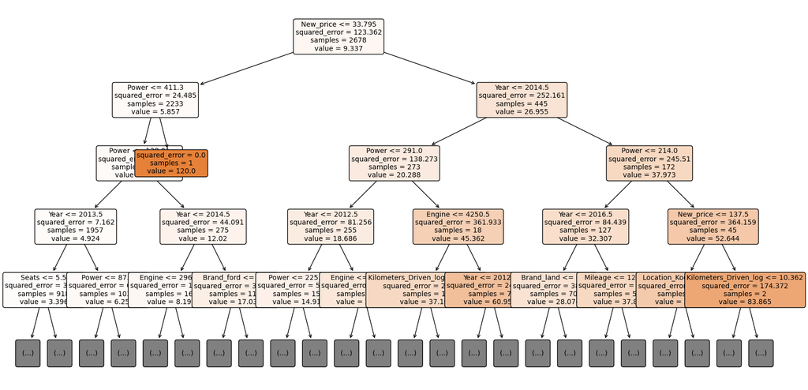

```python
from sklearn.tree import plot_tree

# Extract an estimator (individual tree) from the Random Forest
individual_tree = best_rf_model.estimators_[0]

#Plot the tree
plt.figure(figsize=(20, 10))
plot_tree(individual_tree, feature_names=x_train.columns, filled=True, rounded=True, fontsize=10, max_depth=4)  # Limit depth to 3
plt.show()
```

```python
#Test the best random forest model on the test dataset
model_performance_regression(best_rf_model, x_test, y_test)
```

|  | RMSE | MAE | R-squared | Adj. R-squared | MAPE |
| --- | --- | --- | --- | --- | --- |
| 0 | 2.904936 | 1.535497 | 0.92894 | 0.926707 | 18.205666 |

```python
#Test the best random forest model on the training dataset
model_performance_regression(best_rf_model, x_train, y_train)
```

|  | RMSE | MAE | R-squared | Adj. R-squared | MAPE |
| --- | --- | --- | --- | --- | --- |
| 0 | 1.859476 | 0.980116 | 0.972959 | 0.972601 | 13.909743 |

**Top 10 features after tuning**

```python
#Accessing the important features on tuned model
feature_importance_rf_tune = best_rf_model.feature_importances_
```

```python
#create dictionary to store the names for random forest
feature_importance_dict_rf_tune = dict(zip(feature_names, feature_importance_rf_tune))
```

```python
#Sort features by importance in descending order
sorted_feature_importance_rf_tune = sorted(feature_importance_dict_rf_tune.items(), key=lambda x: x[1], reverse=True)
```

```python
# Print the sorted feature importance
print("Top 10 features")
print("---------------")
for feature, importance in sorted_feature_importance_rf_tune[:10]:
    print(f"{feature}: {importance}")
```

```
Top 10 features
---------------
New_price: 0.5358055789107161
Year: 0.17526708585397568
Power: 0.16731468393792767
Engine: 0.03320337817238477
Kilometers_Driven_log: 0.026409153730819954
Mileage: 0.018332630554956056
Seats: 0.007580388075062751
Location_Hyderabad: 0.004678302637355576
Brand_lamborghini: 0.0038017335402105623
Brand_ford: 0.0026772464760161496
```

## **Conclusions and Recommendations**

**1. Comparison of various techniques and their relative performance based on chosen Metric (Measure of success):**

- How do different techniques perform? Which one is performing relatively better? Is there scope to improve the performance further?

**Executive Summary**

This model did run into some limitations. There were many unique values for the models of the vehicles, and five of the fourteen columns had missing values. The dataset only contained two electric vehicles (EV), and with the shift in manufacturers making more EV’s, this model will need to be updated when there are more used EV’s on the market. Depending on future governmental policies and available charging infrastructure, there may be more of a market for EV’s and less for diesel and petrol vehicles, which make up 99% of the data.

**Linear Regression Model**

```python
# Checking performance on the training data
linear_reg = model_performance_regression(model, x_train, y_train)
linear_reg
```

|  | RMSE | MAE | R-squared | Adj. R-squared | MAPE |
| --- | --- | --- | --- | --- | --- |
| 0 | 5.284223 | 2.921767 | 0.781625 | 0.778736 | 57.261152 |

```python
# Checking performance on the testing data
linear_reg_test = model_performance_regression(model, x_test, y_test)
linear_reg_test
```

|  | RMSE | MAE | R-squared | Adj. R-squared | MAPE |
| --- | --- | --- | --- | --- | --- |
| 0 | 4.664778 | 2.770404 | 0.816763 | 0.811004 | 53.727058 |

**Ridge Regression Model**

```python
#Testing the ridge model on the training data
ridge_reg_train = model_performance_regression(ridge_model, x_train, y_train)
ridge_reg_train
```

|  | RMSE | MAE | R-squared | Adj. R-squared | MAPE |
| --- | --- | --- | --- | --- | --- |
| 0 | 5.351805 | 2.952045 | 0.776003 | 0.77304 | 58.061519 |

```python
#Testing the ridge model on the test data
ridge_reg_test = model_performance_regression(ridge_model, x_test, y_test)
ridge_reg_test
```

|  | RMSE | MAE | R-squared | Adj. R-squared | MAPE |
| --- | --- | --- | --- | --- | --- |
| 0 | 4.62011 | 2.763122 | 0.820256 | 0.814607 | 54.155467 |

**Lasso Regression Model**

```python
#Testing the lasso regression on the training data
lasso_reg_train = model_performance_regression(lasso_model, x_train, y_train)
lasso_reg_train
```

|  | RMSE | MAE | R-squared | Adj. R-squared | MAPE |
| --- | --- | --- | --- | --- | --- |
| 0 | 5.899563 | 3.229175 | 0.727805 | 0.724203 | 61.993361 |

```python
#Testing the lasso regression on the test data
lasso_reg_test = model_performance_regression(lasso_model, x_test, y_test)
lasso_reg_test
```

|  | RMSE | MAE | R-squared | Adj. R-squared | MAPE |
| --- | --- | --- | --- | --- | --- |
| 0 | 5.013799 | 2.973922 | 0.788318 | 0.781665 | 55.496704 |

**Bagging Model**

```python
#Testing the model on the training data
bagging_train = model_performance_regression(bagging_model, x_train, y_train)
bagging_train
```

|  | RMSE | MAE | R-squared | Adj. R-squared | MAPE |
| --- | --- | --- | --- | --- | --- |
| 0 | 1.834404 | 0.61758 | 0.973683 | 0.973335 | 6.97258 |

```python
#Testing the model on the test data
bagging_test = model_performance_regression(bagging_model, x_test, y_test)
bagging_test
```

|  | RMSE | MAE | R-squared | Adj. R-squared | MAPE |
| --- | --- | --- | --- | --- | --- |
| 0 | 2.980435 | 1.483984 | 0.925199 | 0.922848 | 16.494046 |

**Best Decision Tree Model**

```python
#Test the best decision tree on the training data
model_performance_regression(best_tree_model, x_train, y_train)
```

|  | RMSE | MAE | R-squared | Adj. R-squared | MAPE |
| --- | --- | --- | --- | --- | --- |
| 0 | 3.74412 | 1.465814 | 0.890367 | 0.888917 | 16.059574 |

```python
#Test the best decision tree model on the test data
model_performance_regression(best_tree_model, x_test, y_test)
```

|  | RMSE | MAE | R-squared | Adj. R-squared | MAPE |
| --- | --- | --- | --- | --- | --- |
| 0 | 4.328362 | 2.053688 | 0.84224 | 0.837281 | 21.784473 |

**Best Random Forest Model**

```python
#Test the best random forest model on the training dataset
model_performance_regression(best_rf_model, x_train, y_train)
```

|  | RMSE | MAE | R-squared | Adj. R-squared | MAPE |
| --- | --- | --- | --- | --- | --- |
| 0 | 1.859476 | 0.980116 | 0.972959 | 0.972601 | 13.909743 |

```python
#Test the best random forest model on the test dataset
model_performance_regression(best_rf_model, x_test, y_test)
```

|  | RMSE | MAE | R-squared | Adj. R-squared | MAPE |
| --- | --- | --- | --- | --- | --- |
| 0 | 2.904936 | 1.535497 | 0.92894 | 0.926707 | 18.205666 |

**Ranking of models**

1. Tuned Random Forest Model
2. Bagging
3. Tuned Decision Tree
4. Ridge Regression
5. Linear Regression
6. Lasso Regression
- Bagging, Ridge Regression, Linear Regression, and Lasso Regression have the potential to become better through tuning.
- Tuning was only applied to the Random Forest Model and the Decision Tree Model.

**2. Refined insights:**

- What are the most meaningful insights relevant to the problem?

While Random Forest did a good job predicting the price for vehicles, there are some other features to consider. Only brand was considered when creating this model. The model type was left out of the data set as it had too many unique values. It would be worth looking into all the model names and seeing if this will help classify more of them together. Brands such as Bentley, Lamborghini, and Porsche had 20 vehicles in the data set but may have helped skew the price to the right since they are more high-end vehicles. If these brands are not going to be considered when buying vehicles, it may be worth removing them from the dataset.

It is also worth looking into location, as Coimbatore and Bangalore had higher priced vehicles. The residents there may have a higher net worth and may be willing to pay for more expensive vehicles.

This data set also only contained 2 EV’s. Car manufacturers are producing more EV’s, which means in the coming years their will be more used EV’s available. This may affect the price for vehicles that use Petrol or Diesel (99% of the data) since they may become less desirable.

71% of the vehicles included the data set were manual, and this may also negatively impact prices since most vehicles being produced are automatic.

It is also worth tracking the trend of people buying used or new vehicles. If more and more people are buying used vehicles, this may affect the pricing and supply of new vehicles being produced.

Two other pieces of valuable information would be the accident history and the current shape the vehicle is in. People are less inclined to buy used vehicles that are in bad shape and have had a severe accident in its history.

- This dataset had a lot of missing values. I think it would be beneficial to have more complete data.
- It would probably also be helpful to have more vehicles in the dataset.
- The models from Name had too many unique values. There may be a better way to group those.
- Certain car brands like Bentley or lamborghini could probably be removed since both of these cars are much more expensive than others and made up for very little of the data.
- Tuning the other 4 ML Models could have helped produce better results.

**3. Proposal for the final solution design:**

- What model do you propose to be adopted? Why is this the best solution to adopt?

Six different models were created for Cars4U. After some hyperparameter tuning, it was found that the best model was Random Forest. The other five models, from best to worst, were Bagging, Decision Tree, Ridge Regression, Linear Regression, and Lasso Regression. Of these 6 models, only Random Forest and Decision Tree had tuning done. The other models may have performed better with feature engineering, and that is something to consider in the future. Their original scores did not show much promise, and that is why they were not evaluated farther.

**Random Forest Parameters**

```python
best_rf_params
```

```
{'max_depth': 10,
 'min_samples_leaf': 1,
 'min_samples_split': 2,
 'n_estimators': 50}
```

**Random Forest Model**

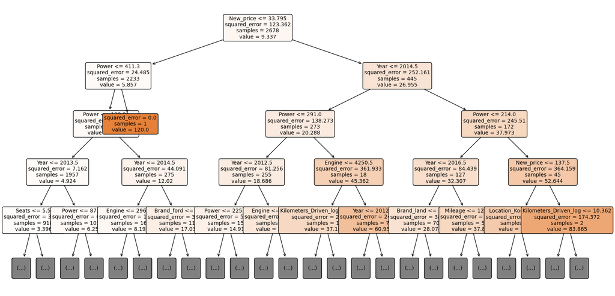

```python
#Plot the tree
plt.figure(figsize=(20, 10))
plot_tree(individual_tree, feature_names=x_train.columns, filled=True, rounded=True, fontsize=10, max_depth=4)  # Limit depth to 4
plt.show()
```